```python
import seaborn as sns
import matplotlib.pyplot as plt
import matplotlib.dates as mdates

sns.set_context('talk')
```

# Predict Bike Sharing Demand with AutoGluon Template

*Analysis and modelling by Elvyna Tunggawan - [@elvyna](http://www.github.com/elvyna)*

## Project: Predict Bike Sharing Demand with AutoGluon

This notebook is a template with each step that you need to complete for the project.

Please fill in your code where there are explicit `?` markers in the notebook. You are welcome to add more cells and code as you see fit.

Once you have completed all the code implementations, please export your notebook as a HTML file so the reviews can view your code. Make sure you have all outputs correctly outputted.

`File-> Export Notebook As... -> Export Notebook as HTML`

There is a writeup to complete as well after all code implememtation is done. Please answer all questions and attach the necessary tables and charts. You can complete the writeup in either markdown or PDF.

Completing the code template and writeup template will cover all of the rubric points for this project.

The rubric contains "Stand Out Suggestions" for enhancing the project beyond the minimum requirements. The stand out suggestions are optional. If you decide to pursue the "stand out suggestions", you can include the code in this notebook and also discuss the results in the writeup file.

## Step 1: Create an account with Kaggle

### Create Kaggle Account and download API key

Below is example of steps to get the API username and key. Each student will have their own username and key.

1. Open account settings.

2. Scroll down to API and click Create New API Token.

3. Open up `kaggle.json` and use the username and key.


## Step 2: Download the Kaggle dataset using the kaggle python library

### Open up Sagemaker Studio and use starter template

1. Notebook should be using a `ml.t3.medium` instance (2 vCPU + 4 GiB)
2. Notebook should be using kernal: `Python 3 (MXNet 1.8 Python 3.7 CPU Optimized)`

### Install packages

```python
INSTALL_PACKAGES = False

if INSTALL_PACKAGES:
    !pip install -U pip
    !pip install -U setuptools wheel
    !pip install -U "mxnet<2.0.0" bokeh==2.0.1
    !pip install autogluon --no-cache-dir
    # Without --no-cache-dir, smaller aws instances may have trouble installing
```

### Setup Kaggle API Key

```python
# Fill in your user name and key from creating the kaggle account and API token file
import json

PREPARE_KAGGLE_CRED = False
if PREPARE_KAGGLE_CRED:
    # create the .kaggle directory and an empty kaggle.json file
    !mkdir -p /root/.kaggle
    !touch /root/.kaggle/kaggle.json
    !chmod 600 /root/.kaggle/kaggle.json

    kaggle_username = "elvyna"
    kaggle_key = "<api-key>" ## remove this later, do not commit when key exist!

    # Save API token the kaggle.json file
    with open("/root/.kaggle/kaggle.json", "w") as f:
        f.write(json.dumps({"username": kaggle_username, "key": kaggle_key}))
```

### Download and explore dataset

#### Go to the bike sharing demand competition and agree to the terms

```python
DOWNLOAD_DATASET = False

if DOWNLOAD_DATASET:
    # Download the dataset, it will be in a .zip file so you'll need to unzip it as well.
    !kaggle competitions download -c bike-sharing-demand
    # If you already downloaded it you can use the -o command to overwrite the file
    !unzip -o bike-sharing-demand.zip

    ## move to data folder to make it tidier
    !mkdir data
    !mv *.csv data/
```

```python
import pandas as pd
from autogluon.tabular import TabularPredictor
```

```python
# Create the train dataset in pandas by reading the csv
# Set the parsing of the datetime column so you can use some of the `dt` features in pandas later
train = pd.read_csv("data/train.csv")
train.head()
```

|  | datetime | season | holiday | workingday | weather | temp | atemp | humidity | windspeed | casual | registered | count |
| --- | --- | --- | --- | --- | --- | --- | --- | --- | --- | --- | --- | --- |
| 0 | 2011-01-01 00:00:00 | 1 | 0 | 0 | 1 | 9.84 | 14.395 | 81 | 0.0 | 3 | 13 | 16 |
| 1 | 2011-01-01 01:00:00 | 1 | 0 | 0 | 1 | 9.02 | 13.635 | 80 | 0.0 | 8 | 32 | 40 |
| 2 | 2011-01-01 02:00:00 | 1 | 0 | 0 | 1 | 9.02 | 13.635 | 80 | 0.0 | 5 | 27 | 32 |
| 3 | 2011-01-01 03:00:00 | 1 | 0 | 0 | 1 | 9.84 | 14.395 | 75 | 0.0 | 3 | 10 | 13 |
| 4 | 2011-01-01 04:00:00 | 1 | 0 | 0 | 1 | 9.84 | 14.395 | 75 | 0.0 | 0 | 1 | 1 |

```python
# Simple output of the train dataset to view some of the min/max/variation of the dataset features.
train.describe()
```

|  | season | holiday | workingday | weather | temp | atemp | humidity | windspeed | casual | registered | count |
| --- | --- | --- | --- | --- | --- | --- | --- | --- | --- | --- | --- |
| count | 10886.000000 | 10886.000000 | 10886.000000 | 10886.000000 | 10886.00000 | 10886.000000 | 10886.000000 | 10886.000000 | 10886.000000 | 10886.000000 | 10886.000000 |
| mean | 2.506614 | 0.028569 | 0.680875 | 1.418427 | 20.23086 | 23.655084 | 61.886460 | 12.799395 | 36.021955 | 155.552177 | 191.574132 |
| std | 1.116174 | 0.166599 | 0.466159 | 0.633839 | 7.79159 | 8.474601 | 19.245033 | 8.164537 | 49.960477 | 151.039033 | 181.144454 |
| min | 1.000000 | 0.000000 | 0.000000 | 1.000000 | 0.82000 | 0.760000 | 0.000000 | 0.000000 | 0.000000 | 0.000000 | 1.000000 |
| 25% | 2.000000 | 0.000000 | 0.000000 | 1.000000 | 13.94000 | 16.665000 | 47.000000 | 7.001500 | 4.000000 | 36.000000 | 42.000000 |
| 50% | 3.000000 | 0.000000 | 1.000000 | 1.000000 | 20.50000 | 24.240000 | 62.000000 | 12.998000 | 17.000000 | 118.000000 | 145.000000 |
| 75% | 4.000000 | 0.000000 | 1.000000 | 2.000000 | 26.24000 | 31.060000 | 77.000000 | 16.997900 | 49.000000 | 222.000000 | 284.000000 |
| max | 4.000000 | 1.000000 | 1.000000 | 4.000000 | 41.00000 | 45.455000 | 100.000000 | 56.996900 | 367.000000 | 886.000000 | 977.000000 |

```python
# Create the test pandas dataframe in pandas by reading the csv, remember to parse the datetime!
test = pd.read_csv("data/test.csv")
test.head()
```

|  | datetime | season | holiday | workingday | weather | temp | atemp | humidity | windspeed |
| --- | --- | --- | --- | --- | --- | --- | --- | --- | --- |
| 0 | 2011-01-20 00:00:00 | 1 | 0 | 1 | 1 | 10.66 | 11.365 | 56 | 26.0027 |
| 1 | 2011-01-20 01:00:00 | 1 | 0 | 1 | 1 | 10.66 | 13.635 | 56 | 0.0000 |
| 2 | 2011-01-20 02:00:00 | 1 | 0 | 1 | 1 | 10.66 | 13.635 | 56 | 0.0000 |
| 3 | 2011-01-20 03:00:00 | 1 | 0 | 1 | 1 | 10.66 | 12.880 | 56 | 11.0014 |
| 4 | 2011-01-20 04:00:00 | 1 | 0 | 1 | 1 | 10.66 | 12.880 | 56 | 11.0014 |

```python
# Same thing as train and test dataset
submission = pd.read_csv("data/sampleSubmission.csv")
submission.head()
```

|  | datetime | count |
| --- | --- | --- |
| 0 | 2011-01-20 00:00:00 | 0 |
| 1 | 2011-01-20 01:00:00 | 0 |
| 2 | 2011-01-20 02:00:00 | 0 |
| 3 | 2011-01-20 03:00:00 | 0 |
| 4 | 2011-01-20 04:00:00 | 0 |

## Step 3: Train a model using AutoGluon’s Tabular Prediction

Requirements:

- We are predicting `count`, so it is the label we are setting.
- Ignore `casual` and `registered` columns as they are also not present in the test dataset.
- Use the `root_mean_squared_error` as the metric to use for evaluation.
- Set a time limit of 10 minutes (600 seconds).
- Use the preset `best_quality` to focus on creating the best model.

```python
## remove features that aren't in the test set from the training input
columns_not_in_test_set = list(
    set(train.columns).difference(
        set(test.columns)
    )
)
## remove target variable
columns_not_in_test_set.remove('count')
print(columns_not_in_test_set)

mask_features = ~(train.columns.isin(columns_not_in_test_set))
features = train.columns[mask_features]
print(f"Input features for training: {features}")
```

```
['registered', 'casual']
Input features for training: Index(['datetime', 'season', 'holiday', 'workingday', 'weather', 'temp',
       'atemp', 'humidity', 'windspeed', 'count'],
      dtype='object')
```

```python
RUN_TRAINING = False

if RUN_TRAINING:
    predictor = TabularPredictor(
        label="count",
        problem_type="regression",
        eval_metric="root_mean_squared_error"
    ).fit(
        train_data=train[features],
        time_limit=600,
        presets="best_quality"
    )
else:
    predictor = TabularPredictor.load("AutogluonModels/ag-20211030_044418/")
```

### Review AutoGluon's training run with ranking of models that did the best.

```python
predictor.fit_summary(verbosity=1)
```

```
*** Summary of fit() ***
Estimated performance of each model:
                     model   score_val  pred_time_val    fit_time  pred_time_val_marginal  fit_time_marginal  stack_level  can_infer  fit_order
0      WeightedEnsemble_L3 -114.938244       7.825761  536.770569                0.002569           0.511375            3       True         20
1   NeuralNetFastAI_BAG_L2 -115.529848       5.661987  458.925857                0.266913          80.782606            2       True         17
2        LightGBMXT_BAG_L2 -116.243675       5.506128  384.396497                0.111054           6.253246            2       True         12
3          CatBoost_BAG_L2 -116.616207       5.425004  391.710912                0.029930          13.567661            2       True         15
4          LightGBM_BAG_L2 -116.943103       5.435606  382.433691                0.040532           4.290440            2       True         13
5           XGBoost_BAG_L2 -117.685154       5.445965  387.967428                0.050891           9.824177            2       True         18
6     ExtraTreesMSE_BAG_L2 -117.886121       5.800203  381.547293                0.405129           3.404042            2       True         16
7      WeightedEnsemble_L2 -118.400933       1.439056  183.152477                0.000505           0.378061            2       True         11
8   RandomForestMSE_BAG_L1 -118.456660       0.374616    5.496489                0.374616           5.496489            1       True          5
9   RandomForestMSE_BAG_L2 -119.435757       5.791689  392.524645                0.396616          14.381394            2       True         14
10   NeuralNetMXNet_BAG_L2 -120.727700       6.999564  441.528860                1.604490          63.385609            2       True         19
11    ExtraTreesMSE_BAG_L1 -128.733445       0.316717    1.627260                0.316717           1.627260            1       True          7
12         LightGBM_BAG_L1 -132.286410       0.434287   13.223114                0.434287          13.223114            1       True          4
13          XGBoost_BAG_L1 -132.308522       0.085216   11.038705                0.085216          11.038705            1       True          9
14         CatBoost_BAG_L1 -132.349692       0.032682   38.386988                0.032682          38.386988            1       True          6
15       LightGBMXT_BAG_L1 -134.088334       2.530819   36.507823                2.530819          36.507823            1       True          3
16  NeuralNetFastAI_BAG_L1 -138.025756       0.429823   94.522746                0.429823          94.522746            1       True          8
17   NeuralNetMXNet_BAG_L1 -141.508482       1.063935  177.277926                1.063935         177.277926            1       True         10
18   KNeighborsUnif_BAG_L1 -160.413078       0.061048    0.039311                0.061048           0.039311            1       True          1
19   KNeighborsDist_BAG_L1 -169.552096       0.065932    0.022887                0.065932           0.022887            1       True          2
Number of models trained: 20
Types of models trained:
{'StackerEnsembleModel_CatBoost', 'StackerEnsembleModel_LGB', 'StackerEnsembleModel_KNN', 'StackerEnsembleModel_RF', 'StackerEnsembleModel_XT', 'StackerEnsembleModel_XGBoost', 'WeightedEnsembleModel', 'StackerEnsembleModel_TabularNeuralNet', 'StackerEnsembleModel_NNFastAiTabular'}
Bagging used: True  (with 10 folds)
Multi-layer stack-ensembling used: True  (with 3 levels)
Feature Metadata (Processed):
(raw dtype, special dtypes):
('float', [])                : 3 | ['temp', 'atemp', 'windspeed']
('int', [])                  : 3 | ['season', 'weather', 'humidity']
('int', ['bool'])            : 2 | ['holiday', 'workingday']
('int', ['datetime_as_int']) : 1 | ['datetime']
*** End of fit() summary ***
```

```
{'model_types': {'KNeighborsUnif_BAG_L1': 'StackerEnsembleModel_KNN',
  'KNeighborsDist_BAG_L1': 'StackerEnsembleModel_KNN',
  'LightGBMXT_BAG_L1': 'StackerEnsembleModel_LGB',
  'LightGBM_BAG_L1': 'StackerEnsembleModel_LGB',
  'RandomForestMSE_BAG_L1': 'StackerEnsembleModel_RF',
  'CatBoost_BAG_L1': 'StackerEnsembleModel_CatBoost',
  'ExtraTreesMSE_BAG_L1': 'StackerEnsembleModel_XT',
  'NeuralNetFastAI_BAG_L1': 'StackerEnsembleModel_NNFastAiTabular',
  'XGBoost_BAG_L1': 'StackerEnsembleModel_XGBoost',
  'NeuralNetMXNet_BAG_L1': 'StackerEnsembleModel_TabularNeuralNet',
  'WeightedEnsemble_L2': 'WeightedEnsembleModel',
  'LightGBMXT_BAG_L2': 'StackerEnsembleModel_LGB',
  'LightGBM_BAG_L2': 'StackerEnsembleModel_LGB',
  'RandomForestMSE_BAG_L2': 'StackerEnsembleModel_RF',
  'CatBoost_BAG_L2': 'StackerEnsembleModel_CatBoost',
  'ExtraTreesMSE_BAG_L2': 'StackerEnsembleModel_XT',
  'NeuralNetFastAI_BAG_L2': 'StackerEnsembleModel_NNFastAiTabular',
  'XGBoost_BAG_L2': 'StackerEnsembleModel_XGBoost',
  'NeuralNetMXNet_BAG_L2': 'StackerEnsembleModel_TabularNeuralNet',
  'WeightedEnsemble_L3': 'WeightedEnsembleModel'},
 'model_performance': {'KNeighborsUnif_BAG_L1': -160.4130779463501,
  'KNeighborsDist_BAG_L1': -169.55209635208928,
  'LightGBMXT_BAG_L1': -134.08833420116997,
  'LightGBM_BAG_L1': -132.28640961443517,
  'RandomForestMSE_BAG_L1': -118.45666016795705,
  'CatBoost_BAG_L1': -132.34969157134555,
  'ExtraTreesMSE_BAG_L1': -128.7334450621692,
  'NeuralNetFastAI_BAG_L1': -138.02575586046004,
  'XGBoost_BAG_L1': -132.30852184526813,
  'NeuralNetMXNet_BAG_L1': -141.5084815363963,
  'WeightedEnsemble_L2': -118.40093297307561,
  'LightGBMXT_BAG_L2': -116.24367505269399,
  'LightGBM_BAG_L2': -116.9431025857494,
  'RandomForestMSE_BAG_L2': -119.43575699434149,
  'CatBoost_BAG_L2': -116.61620672780062,
  'ExtraTreesMSE_BAG_L2': -117.88612100518627,
  'NeuralNetFastAI_BAG_L2': -115.52984775559456,
  'XGBoost_BAG_L2': -117.6851541180829,
  'NeuralNetMXNet_BAG_L2': -120.72769984167022,
  'WeightedEnsemble_L3': -114.93824430204704},
```

[output cut: 199 more lines]

```
 5          18
 6          16
 7          11
 8           5
 9          14
 10         19
 11          7
 12          4
 13          9
 14          6
 15          3
 16          8
 17         10
 18          1
 19          2  }
```

```python
iter1_best_model = predictor.fit_summary(verbosity=0)['model_best']
iter1_eval_metric = predictor.fit_summary(verbosity=0)['model_performance'][iter1_best_model]
print(f"Best model: {iter1_best_model}; score: {iter1_eval_metric}")
print("Hyperparameters: ", predictor.fit_summary(verbosity=0)['model_hyperparams'][iter1_best_model])
```

```
Best model: WeightedEnsemble_L3; score: -114.93824430204704
Hyperparameters:  {'use_orig_features': False, 'max_base_models': 25, 'max_base_models_per_type': 5, 'save_bag_folds': True}
```

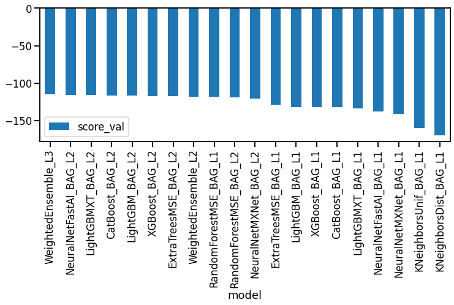

```python
# Output the model's `score_val` in a bar chart to compare performance
predictor.leaderboard(silent=True).plot(
    kind="bar",
    x="model",
    y="score_val",
    figsize=(12,4)
);
```

#### Extra: Check important features learned by the model

```python
## check feature importances
predictor.feature_importance(train)
```

|  | importance | stddev | p_value | n | p99_high | p99_low |
| --- | --- | --- | --- | --- | --- | --- |
| datetime | 1.151500e+02 | 1.908224e+00 | 0.000046 | 3 | 1.260844e+02 | 1.042157e+02 |
| humidity | 8.486729e+01 | 4.016933e+00 | 0.000373 | 3 | 1.078848e+02 | 6.184981e+01 |
| atemp | 8.276735e+01 | 3.680354e+00 | 0.000329 | 3 | 1.038562e+02 | 6.167851e+01 |
| temp | 4.833729e+01 | 2.313263e+00 | 0.000381 | 3 | 6.159254e+01 | 3.508203e+01 |
| windspeed | 3.008711e+01 | 4.721282e+00 | 0.004054 | 3 | 5.714058e+01 | 3.033636e+00 |
| workingday | 1.400946e+01 | 3.210877e+00 | 0.008532 | 3 | 3.240814e+01 | -4.389220e+00 |
| weather | 1.099922e+01 | 8.215827e-01 | 0.000927 | 3 | 1.570698e+01 | 6.291459e+00 |
| holiday | 7.545660e-01 | 1.280635e-01 | 0.004733 | 3 | 1.488384e+00 | 2.074801e-02 |
| registered | 2.497652e-10 | 4.326061e-10 | 0.211325 | 3 | 2.728646e-09 | -2.229116e-09 |
| casual | 0.000000e+00 | 0.000000e+00 | 0.500000 | 3 | 0.000000e+00 | 0.000000e+00 |
| season | -7.327315e-01 | 1.797175e+00 | 0.723372 | 3 | 9.565281e+00 | -1.103074e+01 |

### Create predictions from test dataset

```python
predictions = predictor.predict(test)
predictions.head()
```

```
0     95.318619
1     92.775620
2     92.776901
3    103.854187
4    103.816521
Name: count, dtype: float32
```

#### NOTE: Kaggle will reject the submission if we don't set everything to be > 0.

```python
# Describe the `predictions` series to see if there are any negative values
predictions.describe()
```

```
count    6493.000000
mean      210.743622
std       129.278870
min        -9.224326
25%       104.036850
50%       194.107956
75%       298.885895
max       653.777100
Name: count, dtype: float64
```

```python
# How many negative values do we have?
(predictions < 0).sum()
```

```
4
```

```python
# Set them to zero
mask_negative = (predictions < 0)
predictions[mask_negative] = 0
```

### Set predictions to submission dataframe, save, and submit

```python
submission["count"] = predictions
```

```python
SUBMIT_PREDICTION = False

if SUBMIT_PREDICTION:
    submission.to_csv("submission/submission.csv", index=False)
    !kaggle competitions submit -c bike-sharing-demand -f submission/submission.csv -m "first raw submission"
```

#### View submission via the command line or in the web browser under the competition's page - `My Submissions`

**Note: I ran the code multiple times to try out working on local vs. Sagemaker Studio; that's why there are multiple submissions with the same name.**

```python
!kaggle competitions submissions -c bike-sharing-demand | tail -n +1 | head -n 6
```

```
fileName                     date                 description           status    publicScore  privateScore
---------------------------  -------------------  --------------------  --------  -----------  ------------
submission.csv               2021-10-30 05:02:39  first raw submission  complete  1.39222      1.39222
submission.csv               2021-10-30 05:01:53  first raw submission  error     None         None
submission_new_features.csv  2021-10-29 10:39:34  new features          complete  0.56750      0.56750
submission.csv               2021-10-29 10:15:48  first raw submission  complete  1.39426      1.39426
```

#### Initial score of `1.39222`

## Step 4: Exploratory Data Analysis and Creating an additional feature

- Any additional feature will do, but a great suggestion would be to separate out the datetime into hour, day, or month parts.

```python
def plot_time_series(df: pd.DataFrame, date_column: str, metric_column: str, time_aggregation: str):
    df[date_column] = pd.to_datetime(df[date_column])
    agg = df.groupby(
        pd.Grouper(
            key=date_column,
            freq=time_aggregation
        )
    ).sum()[metric_column].reset_index()

    f, ax = plt.subplots(figsize=(16,4))
    sns.lineplot(
        data=agg,
        x=date_column,
        y=metric_column,
        ax=ax
    )

    ax.xaxis.set_major_formatter(mdates.DateFormatter('%Y-%b'))
    sns.despine();
```

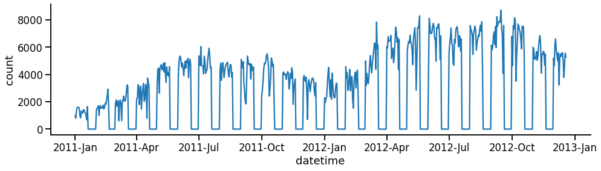

```python
plot_time_series(df=train, date_column='datetime', metric_column='count', time_aggregation='D')
```

Among the original features, some of them are either categorical or boolean values:

- season
- holiday
- workingday
- weather

We might consider generating categories on `temp`, `atemp`, `humidity`, and `windspeed`.

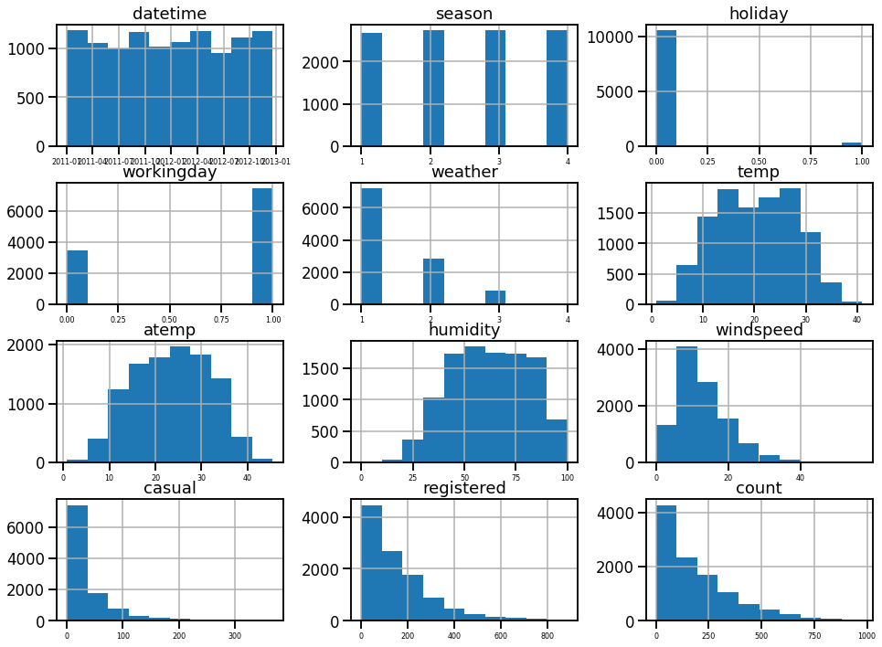

```python
# Create a histogram of all features to show the distribution of each one relative to the data. This is part of the exploritory data analysis
train.hist(figsize=(16,12), xlabelsize=8);
```

We also extract time information from `datetime` column:

- hour
- day: day of month
- day of week: Sunday, Monday, Tuesday, ..., Saturday
- week
- month

```python
def generate_date_features(df: pd.DataFrame) -> pd.DataFrame:
    tmp_datetime = pd.to_datetime(df['datetime'])
    df['hour'] = tmp_datetime.dt.hour
    df['day'] = tmp_datetime.dt.day
    df['day_of_week'] = tmp_datetime.dt.dayofweek
    df['week'] = tmp_datetime.dt.isocalendar().week
    df['month'] = tmp_datetime.dt.month

    return df
```

```python
# create a new feature
train = generate_date_features(df=train)
test = generate_date_features(df=test)
```

### Make category types for these so models know they are not just numbers

- AutoGluon originally sees these as ints, but in reality they are int representations of a category.
- Setting the dtype to category will classify these as categories in AutoGluon.

```python
def convert_to_category_type(df: pd.DataFrame, category_columns: list) -> pd.DataFrame:
    for col in category_columns:
        df[col] = df[col].astype("category")

    return df
```

```python
train = convert_to_category_type(df=train, category_columns=['season','weather','holiday', 'workingday', 'day_of_week'])
test = convert_to_category_type(df=test, category_columns=['season','weather','holiday', 'workingday', 'day_of_week'])
```

```python
# View our new features
train.tail()
```

|  | datetime | season | holiday | workingday | weather | temp | atemp | humidity | windspeed | casual | registered | count | hour | day | day_of_week | week | month |
| --- | --- | --- | --- | --- | --- | --- | --- | --- | --- | --- | --- | --- | --- | --- | --- | --- | --- |
| 10881 | 2012-12-19 19:00:00 | 4 | 0 | 1 | 1 | 15.58 | 19.695 | 50 | 26.0027 | 7 | 329 | 336 | 19 | 19 | 2 | 51 | 12 |
| 10882 | 2012-12-19 20:00:00 | 4 | 0 | 1 | 1 | 14.76 | 17.425 | 57 | 15.0013 | 10 | 231 | 241 | 20 | 19 | 2 | 51 | 12 |
| 10883 | 2012-12-19 21:00:00 | 4 | 0 | 1 | 1 | 13.94 | 15.910 | 61 | 15.0013 | 4 | 164 | 168 | 21 | 19 | 2 | 51 | 12 |
| 10884 | 2012-12-19 22:00:00 | 4 | 0 | 1 | 1 | 13.94 | 17.425 | 61 | 6.0032 | 12 | 117 | 129 | 22 | 19 | 2 | 51 | 12 |
| 10885 | 2012-12-19 23:00:00 | 4 | 0 | 1 | 1 | 13.12 | 16.665 | 66 | 8.9981 | 4 | 84 | 88 | 23 | 19 | 2 | 51 | 12 |

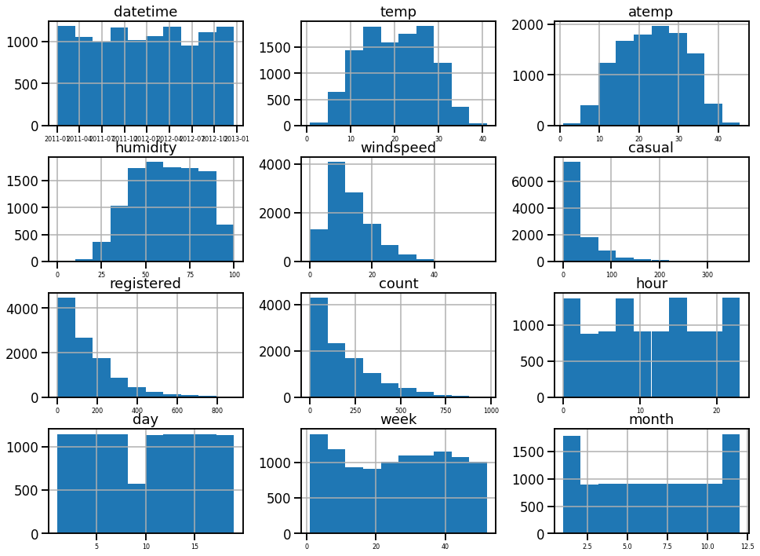

```python
# View histogram of all features again now with the hour feature
train.hist(figsize=(16,12), xlabelsize=8);
```

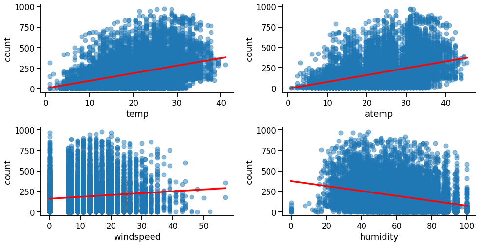

```python
f, ax = plt.subplots(figsize=(16,8), ncols=2, nrows=2)
plt.subplots_adjust(wspace=.25, hspace=.4)

row_idx = 0
col_idx = 0
for idx, col in enumerate(['temp','atemp','windspeed','humidity']):
    sns.regplot(
        data=train,
        x=col,
        y='count',
        line_kws={'color': 'red'},
        scatter_kws={'alpha': .5},
        ci=95,
        ax=ax[row_idx][col_idx]
    )
    if idx % 2 == 0:
        col_idx += 1
    else:
        col_idx = 0
        row_idx += 1

sns.despine();
```

Hour has a moderately positive correlation with the demand (`count`); we could generate additional features based on hour of day - potentially, demand during rush hour is much higher.

```python
import numpy as np

def categorise_hour_activity(df: pd.DataFrame, hour_column: str) -> pd.DataFrame:
    hour_morning_commute = [7,8,9]
    hour_lunch_time = [11,12,13]
    hour_evening_commute = [5,6]

    conditions = [
        df[hour_column].isin(hour_morning_commute),
        df[hour_column].isin(hour_lunch_time),
        df[hour_column].isin(hour_evening_commute),
    ]

    choices = [
        'morning_commute',
        'lunch_time',
        'evening_commute'
    ]

    df['hour_activity'] = np.select(
        condlist=conditions,
        choicelist=choices,
        default='others'
    )

    ## set as category
    df['hour_activity'] = df['hour_activity'].astype("category")
    return df
```

```python
train = categorise_hour_activity(df=train, hour_column='hour')
test = categorise_hour_activity(df=test, hour_column='hour')
```

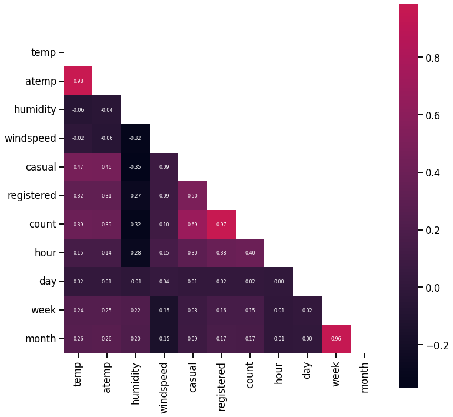

```python
mask = np.zeros_like(train.corr())
mask[np.triu_indices_from(mask)] = True

f, ax = plt.subplots(figsize=(12,12))

sns.heatmap(
    train.corr(),
    mask=mask,
    center=True,
    annot=True,
    annot_kws={'fontsize': 8},
    fmt='.2f',
    square=True,
    cmap='rocket',
    ax=ax
);
```

> season - 1 = spring, 2 = summer, 3 = fall, 4 = winter

Demand distribution during Spring (season = 1) has a narrower distribution than others, i.e., people do not rent the bikes that frequently.

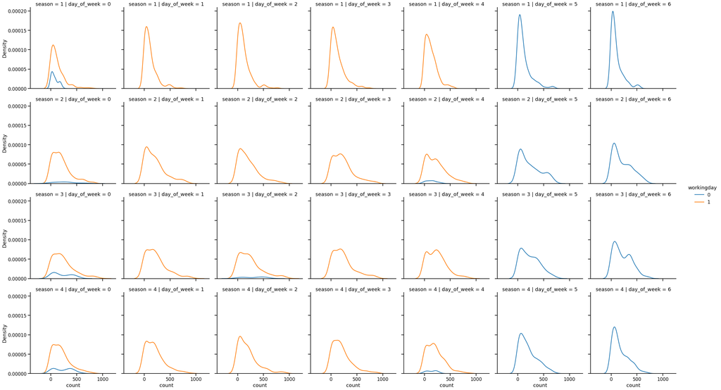

```python
sns.displot(
    data=train,
    x='count',
    row='season',
    col='day_of_week',
    hue='workingday',
    kind='kde'
)

sns.despine();
```

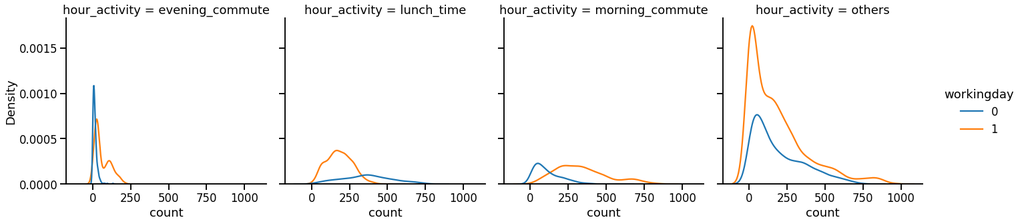

```python
sns.displot(
    data=train,
    x='count',
    col='hour_activity',
    hue='workingday',
    kind='kde'
)

sns.despine();
```

## Step 5: Rerun the model with the same settings as before, just with more features

```python
## remove features that aren't in the test set from the training input
columns_not_in_test_set = list(
    set(train.columns).difference(
        set(test.columns)
    )
)
## remove target variable
columns_not_in_test_set.remove('count')
print(columns_not_in_test_set)

mask_features = ~(train.columns.isin(columns_not_in_test_set))
features = train.columns[mask_features]
print(f"Input features for training: {features}")
```

```
['registered', 'casual']
Input features for training: Index(['datetime', 'season', 'holiday', 'workingday', 'weather', 'temp',
       'atemp', 'humidity', 'windspeed', 'count', 'hour', 'day', 'day_of_week',
       'week', 'month', 'hour_activity'],
      dtype='object')
```

```python
RUN_TRAINING = False

if RUN_TRAINING:
    predictor_new_features = TabularPredictor(
        label="count",
        problem_type="regression",
        eval_metric="root_mean_squared_error"
    ).fit(
        train_data=train[features], ## set more features
        time_limit=600,
        presets="best_quality"
    )
else:
    predictor_new_features = TabularPredictor.load("AutogluonModels/ag-20211030_054945/")
```

```python
predictor_new_features.fit_summary(verbosity=1)
```

```
*** Summary of fit() ***
Estimated performance of each model:
                     model   score_val  pred_time_val    fit_time  pred_time_val_marginal  fit_time_marginal  stack_level  can_infer  fit_order
0      WeightedEnsemble_L3  -31.889886       9.672717  497.081483                0.001243           0.571588            3       True         16
1      WeightedEnsemble_L2  -31.966879       6.259340  104.664701                0.000871           1.030156            2       True          9
2     ExtraTreesMSE_BAG_L2  -32.277686       8.068737  323.671715                0.494477           4.644643            2       True         14
3          CatBoost_BAG_L2  -32.362688       7.692635  362.077271                0.118375          43.050198            2       True         13
4          LightGBM_BAG_L2  -32.381617       7.717220  325.637426                0.142960           6.610353            2       True         11
5   RandomForestMSE_BAG_L2  -32.502782       8.071102  332.636301                0.496842          13.609228            2       True         12
6        LightGBMXT_BAG_L2  -33.059496       7.755059  330.164855                0.180799          11.137783            2       True         10
7          LightGBM_BAG_L1  -33.318929       1.430353   29.319949                1.430353          29.319949            1       True          4
8        LightGBMXT_BAG_L1  -33.712713       4.088071   66.211192                4.088071          66.211192            1       True          3
9   NeuralNetFastAI_BAG_L2  -33.821069       8.418821  428.595472                0.844561         109.568400            2       True         15
10    ExtraTreesMSE_BAG_L1  -38.120493       0.371377    2.597341                0.371377           2.597341            1       True          6
11  RandomForestMSE_BAG_L1  -38.428866       0.368668    5.506063                0.368668           5.506063            1       True          5
12    LightGBMLarge_BAG_L1  -52.413153       0.171769    4.943305                0.171769           4.943305            1       True          8
13  NeuralNetFastAI_BAG_L1  -55.251147       0.943584  210.370617                0.943584         210.370617            1       True          7
14   KNeighborsDist_BAG_L1 -119.373394       0.097399    0.037382                0.097399           0.037382            1       True          2
15   KNeighborsUnif_BAG_L1 -123.922640       0.103038    0.041223                0.103038           0.041223            1       True          1
Number of models trained: 16
Types of models trained:
{'StackerEnsembleModel_CatBoost', 'StackerEnsembleModel_LGB', 'StackerEnsembleModel_KNN', 'StackerEnsembleModel_RF', 'StackerEnsembleModel_XT', 'WeightedEnsembleModel', 'StackerEnsembleModel_NNFastAiTabular'}
Bagging used: True  (with 10 folds)
Multi-layer stack-ensembling used: True  (with 3 levels)
Feature Metadata (Processed):
(raw dtype, special dtypes):
('category', [])             : 4 | ['season', 'weather', 'day_of_week', 'hour_activity']
('float', [])                : 3 | ['temp', 'atemp', 'windspeed']
('int', [])                  : 4 | ['humidity', 'hour', 'day', 'month']
('int', ['bool'])            : 2 | ['holiday', 'workingday']
('int', ['datetime_as_int']) : 1 | ['datetime']
*** End of fit() summary ***
```

```
{'model_types': {'KNeighborsUnif_BAG_L1': 'StackerEnsembleModel_KNN',
  'KNeighborsDist_BAG_L1': 'StackerEnsembleModel_KNN',
  'LightGBMXT_BAG_L1': 'StackerEnsembleModel_LGB',
  'LightGBM_BAG_L1': 'StackerEnsembleModel_LGB',
  'RandomForestMSE_BAG_L1': 'StackerEnsembleModel_RF',
  'ExtraTreesMSE_BAG_L1': 'StackerEnsembleModel_XT',
  'NeuralNetFastAI_BAG_L1': 'StackerEnsembleModel_NNFastAiTabular',
  'LightGBMLarge_BAG_L1': 'StackerEnsembleModel_LGB',
  'WeightedEnsemble_L2': 'WeightedEnsembleModel',
  'LightGBMXT_BAG_L2': 'StackerEnsembleModel_LGB',
  'LightGBM_BAG_L2': 'StackerEnsembleModel_LGB',
  'RandomForestMSE_BAG_L2': 'StackerEnsembleModel_RF',
  'CatBoost_BAG_L2': 'StackerEnsembleModel_CatBoost',
  'ExtraTreesMSE_BAG_L2': 'StackerEnsembleModel_XT',
  'NeuralNetFastAI_BAG_L2': 'StackerEnsembleModel_NNFastAiTabular',
  'WeightedEnsemble_L3': 'WeightedEnsembleModel'},
 'model_performance': {'KNeighborsUnif_BAG_L1': -123.92263994015985,
  'KNeighborsDist_BAG_L1': -119.37339448003198,
  'LightGBMXT_BAG_L1': -33.71271280596067,
  'LightGBM_BAG_L1': -33.31892882325422,
  'RandomForestMSE_BAG_L1': -38.428866179968324,
  'ExtraTreesMSE_BAG_L1': -38.120493244073245,
  'NeuralNetFastAI_BAG_L1': -55.251146759855,
  'LightGBMLarge_BAG_L1': -52.4131525426315,
  'WeightedEnsemble_L2': -31.966878688611473,
  'LightGBMXT_BAG_L2': -33.05949607758555,
  'LightGBM_BAG_L2': -32.381617335046485,
  'RandomForestMSE_BAG_L2': -32.50278171344537,
  'CatBoost_BAG_L2': -32.362687898814684,
  'ExtraTreesMSE_BAG_L2': -32.27768640069647,
  'NeuralNetFastAI_BAG_L2': -33.82106880018818,
  'WeightedEnsemble_L3': -31.88988567364456},
 'model_best': 'WeightedEnsemble_L3',
 'model_paths': {'KNeighborsUnif_BAG_L1': 'AutogluonModels/ag-20211030_054945/models/KNeighborsUnif_BAG_L1/',
  'KNeighborsDist_BAG_L1': 'AutogluonModels/ag-20211030_054945/models/KNeighborsDist_BAG_L1/',
  'LightGBMXT_BAG_L1': 'AutogluonModels/ag-20211030_054945/models/LightGBMXT_BAG_L1/',
  'LightGBM_BAG_L1': 'AutogluonModels/ag-20211030_054945/models/LightGBM_BAG_L1/',
  'RandomForestMSE_BAG_L1': 'AutogluonModels/ag-20211030_054945/models/RandomForestMSE_BAG_L1/',
  'ExtraTreesMSE_BAG_L1': 'AutogluonModels/ag-20211030_054945/models/ExtraTreesMSE_BAG_L1/',
  'NeuralNetFastAI_BAG_L1': 'AutogluonModels/ag-20211030_054945/models/NeuralNetFastAI_BAG_L1/',
```

[output cut: 151 more lines]

```
 1           9
 2          14
 3          13
 4          11
 5          12
 6          10
 7           4
 8           3
 9          15
 10          6
 11          5
 12          8
 13          7
 14          2
 15          1  }
```

```python
iter2_best_model = predictor_new_features.fit_summary(verbosity=0)['model_best']
iter2_eval_metric = predictor_new_features.fit_summary(verbosity=0)['model_performance'][iter2_best_model]
print(f"Best model: {iter2_best_model}; score: {iter2_eval_metric}")
print("Hyperparameters: ", predictor_new_features.fit_summary(verbosity=0)['model_hyperparams'][iter2_best_model])
```

```
Best model: WeightedEnsemble_L3; score: -31.88988567364456
Hyperparameters:  {'use_orig_features': False, 'max_base_models': 25, 'max_base_models_per_type': 5, 'save_bag_folds': True}
```

#### Extra: Check important features learned by the model

```python
## check feature importances
predictor_new_features.feature_importance(train)
```

|  | importance | stddev | p_value | n | p99_high | p99_low |
| --- | --- | --- | --- | --- | --- | --- |
| hour | 179.721047 | 3.558150 | 0.000065 | 3 | 200.109643 | 159.332452 |
| datetime | 77.205369 | 4.855880 | 0.000658 | 3 | 105.030098 | 49.380639 |
| workingday | 65.082721 | 3.803280 | 0.000568 | 3 | 86.875936 | 43.289507 |
| hour_activity | 38.844590 | 6.488732 | 0.004587 | 3 | 76.025746 | 1.663434 |
| day_of_week | 25.266460 | 0.944787 | 0.000233 | 3 | 30.680195 | 19.852726 |
| humidity | 25.255862 | 2.468341 | 0.001584 | 3 | 39.399729 | 11.111996 |
| temp | 22.893519 | 0.999786 | 0.000318 | 3 | 28.622405 | 17.164633 |
| atemp | 14.929997 | 1.405384 | 0.001470 | 3 | 22.983003 | 6.876990 |
| weather | 14.842003 | 1.298088 | 0.001270 | 3 | 22.280192 | 7.403814 |
| day | 7.060410 | 0.305547 | 0.000312 | 3 | 8.811227 | 5.309593 |
| windspeed | 4.468719 | 0.364988 | 0.001108 | 3 | 6.560138 | 2.377300 |
| month | 4.144123 | 0.348200 | 0.001172 | 3 | 6.139345 | 2.148901 |
| season | 3.262711 | 0.692489 | 0.007343 | 3 | 7.230751 | -0.705329 |
| holiday | 1.315591 | 0.440499 | 0.017699 | 3 | 3.839700 | -1.208519 |
| casual | 0.000000 | 0.000000 | 0.500000 | 3 | 0.000000 | 0.000000 |
| registered | 0.000000 | 0.000000 | 0.500000 | 3 | 0.000000 | 0.000000 |
| week | 0.000000 | 0.000000 | 0.500000 | 3 | 0.000000 | 0.000000 |

### Create predictions on the test set & submit to Kaggle

```python
## predict on the test set
predictions = predictor_new_features.predict(test)

# Remember to set all negative values to zero
mask_negative = (predictions < 0)
predictions[mask_negative] = 0
```

```python
# Same submitting predictions
submission_new_features = submission.copy()

submission_new_features["count"] = predictions
```

```python
SUBMIT_PREDICTION = False

if SUBMIT_PREDICTION:
    submission_new_features.to_csv("submission/submission_new_features.csv", index=False)
    !kaggle competitions submit -c bike-sharing-demand -f submission/submission_new_features.csv -m "more features"
```

```
Successfully submitted to Bike Sharing Demand
```

```python
!kaggle competitions submissions -c bike-sharing-demand | tail -n +1 | head -n 6
```

```
fileName                     date                 description           status    publicScore  privateScore
---------------------------  -------------------  --------------------  --------  -----------  ------------
submission_new_features.csv  2021-10-30 06:14:22  more features         complete  0.45711      0.45711
submission.csv               2021-10-30 05:02:39  first raw submission  complete  1.39222      1.39222
submission.csv               2021-10-30 05:01:53  first raw submission  error     None         None
submission_new_features.csv  2021-10-29 10:39:34  new features          complete  0.56750      0.56750
```

#### New Score of `0.45711`

## Step 6: Hyper parameter optimization

- There are many options for hyper parameter optimization.
- Options are to change the AutoGluon higher level parameters or the individual model hyperparameters.
- The hyperparameters of the models themselves that are in AutoGluon. Those need the `hyperparameter` and `hyperparameter_tune_kwargs` arguments.

```python
## remove features that aren't in the test set from the training input
columns_not_in_test_set = list(
    set(train.columns).difference(
        set(test.columns)
    )
)
## remove target variable
columns_not_in_test_set.remove('count')
print(columns_not_in_test_set)

mask_features = ~(train.columns.isin(columns_not_in_test_set))
features = train.columns[mask_features]
print(f"Input features for training: {features}")
```

```
['registered', 'casual']
Input features for training: Index(['datetime', 'season', 'holiday', 'workingday', 'weather', 'temp',
       'atemp', 'humidity', 'windspeed', 'count', 'hour', 'day', 'day_of_week',
       'week', 'month', 'hour_activity'],
      dtype='object')
```

### AutoGluon Higher Level HPO Iteration 1: Initial Features

Use original features - with adjusted data types for the categorical values.

```python
original_features = [
    'datetime', 'season', 'holiday', 'workingday', 'weather', 'temp',
    'atemp', 'humidity', 'windspeed', 'count'
]
```

```python
time_limit = 2*60  # train various models for ~2 min
num_trials = 5  # try at most 5 different hyperparameter configurations for each type of model
search_strategy = 'auto'  # to tune hyperparameters using Bayesian optimization routine with a local scheduler

hp_tuning_dict = {
    'num_trials': num_trials,
    'scheduler' : 'local',
    'searcher': search_strategy,
}
```

```python
RUN_TRAINING = False

if RUN_TRAINING:
    predictor_hpo_initial = TabularPredictor(
        label="count",
        problem_type="regression",
        eval_metric="root_mean_squared_error"
    ).fit(
        train_data=train[original_features], ## set more features
        time_limit=600,
        presets="best_quality",
        hyperparameter_tune_kwargs=hp_tuning_dict,
    )
else:
    predictor_hpo_initial = TabularPredictor.load("AutogluonModels/ag-20211031_005214/")
```

[output not shown]

```
[1000]	train_set's rmse: 120.046	valid_set's rmse: 133.384
```

```
	Time limit exceeded
Fitted model: LightGBMXT_BAG_L1/T0 ...
	-133.2491	 = Validation score   (root_mean_squared_error)
	2.02s	 = Training   runtime
	0.04s	 = Validation runtime
Hyperparameter tuning model: LightGBM_BAG_L1 ...
```

[output not shown]

```
	Time limit exceeded
Fitted model: XGBoost_BAG_L1/T0 ...
	-128.9841	 = Validation score   (root_mean_squared_error)
	1.25s	 = Training   runtime
	0.02s	 = Validation runtime
Hyperparameter tuning model: NeuralNetMXNet_BAG_L1 ...
```

[output not shown]

```
[1000]	train_set's rmse: 121.241	valid_set's rmse: 127.161
```

```
[1000]	train_set's rmse: 120.145	valid_set's rmse: 138.053
[2000]	train_set's rmse: 113.109	valid_set's rmse: 136.941
```

```
[1000]	train_set's rmse: 121.032	valid_set's rmse: 126.718
[2000]	train_set's rmse: 113.907	valid_set's rmse: 125.849
[3000]	train_set's rmse: 109.062	valid_set's rmse: 125.52
```

```
[1000]	train_set's rmse: 120.471	valid_set's rmse: 133.302
[2000]	train_set's rmse: 113.546	valid_set's rmse: 131.92
[3000]	train_set's rmse: 108.793	valid_set's rmse: 131.323
[4000]	train_set's rmse: 105.051	valid_set's rmse: 131.362
```

```
[1000]	train_set's rmse: 120.026	valid_set's rmse: 137.71
[2000]	train_set's rmse: 113.209	valid_set's rmse: 136.984
[3000]	train_set's rmse: 108.39	valid_set's rmse: 136.792
```

```
[1000]	train_set's rmse: 120.26	valid_set's rmse: 133.988
[2000]	train_set's rmse: 113.375	valid_set's rmse: 133.538
[3000]	train_set's rmse: 108.583	valid_set's rmse: 133.124
```

```
[1000]	train_set's rmse: 120.585	valid_set's rmse: 130.934
```

```
	-133.3432	 = Validation score   (root_mean_squared_error)
	20.99s	 = Training   runtime
	1.21s	 = Validation runtime
Fitting model: LightGBM_BAG_L1/T0 ... Training model for up to 342.76s of the 542.81s of remaining time.
```

```
[1000]	train_set's rmse: 96.0159	valid_set's rmse: 122.919
```

```
[1000]	train_set's rmse: 93.6973	valid_set's rmse: 137.047
```

```
[1000]	train_set's rmse: 94.8965	valid_set's rmse: 131.303
```

[output not shown]

```
[1000]	train_set's rmse: 93.6973	valid_set's rmse: 137.047
```

```
[1000]	train_set's rmse: 94.8965	valid_set's rmse: 131.303
```

[output not shown]

```
[1000]	train_set's rmse: 93.6973	valid_set's rmse: 137.047
```

```
[1000]	train_set's rmse: 94.8965	valid_set's rmse: 131.303
```

[output not shown]

```
	Time limit exceeded
Fitted model: CatBoost_BAG_L2/T0 ...
	-113.2746	 = Validation score   (root_mean_squared_error)
	2.28s	 = Training   runtime
	0.19s	 = Validation runtime
Hyperparameter tuning model: ExtraTreesMSE_BAG_L2 ...
Fitted model: ExtraTreesMSE_BAG_L2/T0 ...
	-117.9133	 = Validation score   (root_mean_squared_error)
	2.94s	 = Training   runtime
	0.39s	 = Validation runtime
Hyperparameter tuning model: NeuralNetFastAI_BAG_L2 ...
	Ran out of time, stopping training early. (Stopping on epoch 0)
Fitted model: NeuralNetFastAI_BAG_L2/T0 ...
	-115.4529	 = Validation score   (root_mean_squared_error)
	2.72s	 = Training   runtime
	0.07s	 = Validation runtime
Hyperparameter tuning model: XGBoost_BAG_L2 ...
```

```
	Time limit exceeded
Fitted model: XGBoost_BAG_L2/T0 ...
	-110.3103	 = Validation score   (root_mean_squared_error)
	1.02s	 = Training   runtime
	0.01s	 = Validation runtime
Hyperparameter tuning model: NeuralNetMXNet_BAG_L2 ...
```

[output not shown]

[output cut: 8 more lines]

```
	106.32s	 = Training   runtime
	0.37s	 = Validation runtime
Fitting model: XGBoost_BAG_L2/T0 ... Training model for up to 5.69s of the 5.68s of remaining time.
	-117.346	 = Validation score   (root_mean_squared_error)
	6.34s	 = Training   runtime
	0.08s	 = Validation runtime
Fitting model: NeuralNetMXNet_BAG_L2/T0 ... Training model for up to 0.04s of the 0.03s of remaining time.
	Time limit exceeded... Skipping NeuralNetMXNet_BAG_L2/T0.
Completed 1/20 k-fold bagging repeats ...
Fitting model: WeightedEnsemble_L3 ... Training model for up to 360.0s of the -0.58s of remaining time.
	-115.1284	 = Validation score   (root_mean_squared_error)
	0.36s	 = Training   runtime
	0.0s	 = Validation runtime
AutoGluon training complete, total runtime = 600.99s ...
TabularPredictor saved. To load, use: predictor = TabularPredictor.load("AutogluonModels/ag-20211031_005214/")
```

```python
predictor_hpo_initial.fit_summary(verbosity=1)
```

```
*** Summary of fit() ***
Estimated performance of each model:
                        model   score_val  pred_time_val    fit_time  pred_time_val_marginal  fit_time_marginal  stack_level  can_infer  fit_order
0        LightGBMLarge_BAG_L2 -111.732265       4.435898  356.477184                0.007497           1.120990            2       True         23
1         WeightedEnsemble_L3 -115.128397       5.465188  482.132098                0.000564           0.364992            3       True         24
2   NeuralNetFastAI_BAG_L2/T0 -116.125603       4.801332  461.674882                0.372932         106.318689            2       True         20
3        LightGBMXT_BAG_L2/T0 -116.234219       4.560488  361.642810                0.132087           6.286617            2       True         13
4        LightGBMXT_BAG_L2/T1 -116.279765       4.578180  362.097913                0.149780           6.741719            2       True         14
5          CatBoost_BAG_L2/T0 -116.761721       4.896350  382.471959                0.467950          27.115766            2       True         18
6          LightGBM_BAG_L2/T0 -116.975572       4.490074  359.876550                0.061673           4.520357            2       True         15
7          LightGBM_BAG_L2/T1 -117.054607       4.499777  360.624475                0.071377           5.268282            2       True         16
8           XGBoost_BAG_L2/T0 -117.345972       4.507059  361.697488                0.078659           6.341294            2       True         21
9     ExtraTreesMSE_BAG_L2/T0 -117.913346       4.819272  358.300149                0.390872           2.943956            2       True         19
10        WeightedEnsemble_L2 -118.455003       1.906468  297.009521                0.000473           0.332179            2       True         12
11  RandomForestMSE_BAG_L1/T0 -118.459395       0.311817    3.306603                0.311817           3.306603            1       True          7
12  RandomForestMSE_BAG_L2/T0 -119.303517       4.832624  371.195551                0.404224          15.839357            2       True         17
13    ExtraTreesMSE_BAG_L1/T0 -128.752135       0.315052    1.441994                0.315052           1.441994            1       True          8
14       LightGBMLarge_BAG_L1 -130.211861       0.015176    1.069392                0.015176           1.069392            1       True         11
15          XGBoost_BAG_L1/T0 -132.007657       0.105665    9.082107                0.105665           9.082107            1       True          9
16         LightGBM_BAG_L1/T1 -132.196556       0.303819    8.663421                0.303819           8.663421            1       True          5
17         LightGBM_BAG_L1/T0 -132.303912       0.245154    8.942592                0.245154           8.942592            1       True          4
18         LightGBM_BAG_L1/T2 -132.388819       0.250515    9.454633                0.250515           9.454633            1       True          6
19       LightGBMXT_BAG_L1/T0 -133.343174       1.213461   20.986215                1.213461          20.986215            1       True          3
20   NeuralNetMXNet_BAG_L1/T0 -148.978196       1.594178  293.370739                1.594178         293.370739            1       True         10
21   KNeighborsUnif_BAG_L1/T0 -164.889972       0.044741    0.090068                0.044741           0.090068            1       True          1
22   KNeighborsDist_BAG_L1/T0 -179.133407       0.043998    0.017822                0.043998           0.017822            1       True          2
23   NeuralNetMXNet_BAG_L2/T0 -213.606354       4.470741  355.936060                0.042341           0.579866            2       True         22
Number of models trained: 24
Types of models trained:
{'StackerEnsembleModel_CatBoost', 'StackerEnsembleModel_LGB', 'StackerEnsembleModel_KNN', 'StackerEnsembleModel_RF', 'StackerEnsembleModel_XT', 'StackerEnsembleModel_XGBoost', 'WeightedEnsembleModel', 'StackerEnsembleModel_TabularNeuralNet', 'StackerEnsembleModel_NNFastAiTabular'}
Bagging used: True  (with 10 folds)
Multi-layer stack-ensembling used: True  (with 3 levels)
Feature Metadata (Processed):
(raw dtype, special dtypes):
('category', [])             : 2 | ['season', 'weather']
('float', [])                : 3 | ['temp', 'atemp', 'windspeed']
('int', [])                  : 1 | ['humidity']
('int', ['bool'])            : 2 | ['holiday', 'workingday']
('int', ['datetime_as_int']) : 1 | ['datetime']
*** End of fit() summary ***
```

```
{'model_types': {'KNeighborsUnif_BAG_L1/T0': 'StackerEnsembleModel_KNN',
  'KNeighborsDist_BAG_L1/T0': 'StackerEnsembleModel_KNN',
  'LightGBMXT_BAG_L1/T0': 'StackerEnsembleModel_LGB',
  'LightGBM_BAG_L1/T0': 'StackerEnsembleModel_LGB',
  'LightGBM_BAG_L1/T1': 'StackerEnsembleModel_LGB',
  'LightGBM_BAG_L1/T2': 'StackerEnsembleModel_LGB',
  'RandomForestMSE_BAG_L1/T0': 'StackerEnsembleModel_RF',
  'ExtraTreesMSE_BAG_L1/T0': 'StackerEnsembleModel_XT',
  'XGBoost_BAG_L1/T0': 'StackerEnsembleModel_XGBoost',
  'NeuralNetMXNet_BAG_L1/T0': 'StackerEnsembleModel_TabularNeuralNet',
  'LightGBMLarge_BAG_L1': 'StackerEnsembleModel_LGB',
  'WeightedEnsemble_L2': 'WeightedEnsembleModel',
  'LightGBMXT_BAG_L2/T0': 'StackerEnsembleModel_LGB',
  'LightGBMXT_BAG_L2/T1': 'StackerEnsembleModel_LGB',
  'LightGBM_BAG_L2/T0': 'StackerEnsembleModel_LGB',
  'LightGBM_BAG_L2/T1': 'StackerEnsembleModel_LGB',
  'RandomForestMSE_BAG_L2/T0': 'StackerEnsembleModel_RF',
  'CatBoost_BAG_L2/T0': 'StackerEnsembleModel_CatBoost',
  'ExtraTreesMSE_BAG_L2/T0': 'StackerEnsembleModel_XT',
  'NeuralNetFastAI_BAG_L2/T0': 'StackerEnsembleModel_NNFastAiTabular',
  'XGBoost_BAG_L2/T0': 'StackerEnsembleModel_XGBoost',
  'NeuralNetMXNet_BAG_L2/T0': 'StackerEnsembleModel_TabularNeuralNet',
  'LightGBMLarge_BAG_L2': 'StackerEnsembleModel_LGB',
  'WeightedEnsemble_L3': 'WeightedEnsembleModel'},
 'model_performance': {'KNeighborsUnif_BAG_L1/T0': -164.8899720329543,
  'KNeighborsDist_BAG_L1/T0': -179.13340722310159,
  'LightGBMXT_BAG_L1/T0': -133.3431737964172,
  'LightGBM_BAG_L1/T0': -132.3039118873257,
  'LightGBM_BAG_L1/T1': -132.1965563389119,
  'LightGBM_BAG_L1/T2': -132.38881853974416,
  'RandomForestMSE_BAG_L1/T0': -118.45939523368254,
  'ExtraTreesMSE_BAG_L1/T0': -128.75213488083233,
  'XGBoost_BAG_L1/T0': -132.0076565675768,
  'NeuralNetMXNet_BAG_L1/T0': -148.97819553903014,
  'LightGBMLarge_BAG_L1': -130.21186144318713,
  'WeightedEnsemble_L2': -118.45500293240916,
  'LightGBMXT_BAG_L2/T0': -116.23421887966252,
  'LightGBMXT_BAG_L2/T1': -116.27976512837482,
  'LightGBM_BAG_L2/T0': -116.9755724162628,
  'LightGBM_BAG_L2/T1': -117.05460652535918,
```

[output cut: 247 more lines]

```
 9          19
 10         12
 11          7
 12         17
 13          8
 14         11
 15          9
 16          5
 17          4
 18          6
 19          3
 20         10
 21          1
 22          2
 23         22  }
```

```python
iter3_best_model = predictor_hpo_initial.fit_summary(verbosity=0)['model_best']
iter3_eval_metric = predictor_hpo_initial.fit_summary(verbosity=0)['model_performance'][iter3_best_model]
print(f"Best model: {iter3_best_model}; score: {iter3_eval_metric}")
print("Hyperparameters: ", predictor_hpo_initial.fit_summary(verbosity=0)['model_hyperparams'][iter3_best_model])
```

```
Best model: WeightedEnsemble_L3; score: -115.12839650919979
Hyperparameters:  {'use_orig_features': False, 'max_base_models': 25, 'max_base_models_per_type': 5, 'save_bag_folds': True}
```

#### Extra: Check important features learned by the model

```python
## check feature importances
predictor_hpo_initial.feature_importance(train)
```

```
Computing feature importance via permutation shuffling for 17 features using 1000 rows with 3 shuffle sets...
	2516.77s	= Expected runtime (838.92s per shuffle set)
	231.37s	= Actual runtime (Completed 3 of 3 shuffle sets)
```

|  | importance | stddev | p_value | n | p99_high | p99_low |
| --- | --- | --- | --- | --- | --- | --- |
| datetime | 1.104595e+02 | 2.054188e+00 | 0.000058 | 3 | 1.222302e+02 | 9.868874e+01 |
| humidity | 8.361563e+01 | 4.878560e+00 | 0.000566 | 3 | 1.115703e+02 | 5.566094e+01 |
| atemp | 7.991947e+01 | 3.886888e+00 | 0.000394 | 3 | 1.021918e+02 | 5.764717e+01 |
| temp | 4.721701e+01 | 1.953780e+00 | 0.000285 | 3 | 5.841239e+01 | 3.602164e+01 |
| windspeed | 2.937626e+01 | 4.720091e+00 | 0.004248 | 3 | 5.642291e+01 | 2.329612e+00 |
| workingday | 1.348904e+01 | 2.556193e+00 | 0.005880 | 3 | 2.813631e+01 | -1.158229e+00 |
| weather | 1.122929e+01 | 1.611753e+00 | 0.003399 | 3 | 2.046481e+01 | 1.993765e+00 |
| season | 1.121340e+00 | 1.785640e+00 | 0.195174 | 3 | 1.135325e+01 | -9.110575e+00 |
| holiday | 8.408123e-01 | 1.036183e-01 | 0.002512 | 3 | 1.434556e+00 | 2.470682e-01 |
| hour_activity | 7.106021e-08 | 1.893232e-07 | 0.291162 | 3 | 1.155903e-06 | -1.013783e-06 |
| month | 8.900495e-11 | 1.330331e-09 | 0.459166 | 3 | 7.711949e-09 | -7.533939e-09 |
| casual | 0.000000e+00 | 0.000000e+00 | 0.500000 | 3 | 0.000000e+00 | 0.000000e+00 |
| registered | 0.000000e+00 | 0.000000e+00 | 0.500000 | 3 | 0.000000e+00 | 0.000000e+00 |
| day | 0.000000e+00 | 0.000000e+00 | 0.500000 | 3 | 0.000000e+00 | 0.000000e+00 |
| week | 0.000000e+00 | 0.000000e+00 | 0.500000 | 3 | 0.000000e+00 | 0.000000e+00 |
| day_of_week | -3.228232e-12 | 6.596134e-10 | 0.502997 | 3 | 3.776430e-09 | -3.782886e-09 |
| hour | -9.465850e-11 | 1.639533e-10 | 0.788675 | 3 | 8.448123e-10 | -1.034129e-09 |

#### Create predictions on the test set

```python
## predict on the test set
predictions = predictor_hpo_initial.predict(test)

# Remember to set all negative values to zero
mask_negative = (predictions < 0)
predictions[mask_negative] = 0

# Same submitting predictions
submission_hpo_initial = submission.copy()

submission_hpo_initial["count"] = predictions
```

```python
SUBMIT_PREDICTION = False

if SUBMIT_PREDICTION:
    submission_hpo_initial.to_csv("submission/submission_hpo_initial.csv", index=False)
    !kaggle competitions submit -c bike-sharing-demand -f submission/submission_hpo_initial.csv -m "initial features with basic hpo"
```

```
Successfully submitted to Bike Sharing Demand
```

```python
!kaggle competitions submissions -c bike-sharing-demand | tail -n +1 | head -n 6
```

```
fileName                     date                 description                            status    publicScore  privateScore
---------------------------  -------------------  -------------------------------------  --------  -----------  ------------
submission_hpo_initial.csv   2021-10-31 01:15:26  initial features with basic hpo        complete  1.38739      1.38739
submission_new_hpo_3.csv     2021-10-30 22:54:37  new features with hyperparameters #2   complete  0.46126      0.46126
submission_new_hpo_2.csv     2021-10-30 22:31:27  new features with hyperparameters #1   complete  0.46025      0.46025
submission_new_hpo.csv       2021-10-30 11:00:36  fnew features with hyperparameters #0  complete  0.49612      0.49612
```

#### New Score of `1.38739`

### AutoGluon Higher Level HPO Iteration 2: Additional features

```python
time_limit = 2*60  # train various models for ~2 min
num_trials = 5  # try at most 5 different hyperparameter configurations for each type of model
search_strategy = 'auto'  # to tune hyperparameters using Bayesian optimization routine with a local scheduler

hp_tuning_dict = {
    'num_trials': num_trials,
    'scheduler' : 'local',
    'searcher': search_strategy,
}
```

```python
RUN_TRAINING = False

if RUN_TRAINING:
    predictor_hpo_more_features = TabularPredictor(
        label="count",
        problem_type="regression",
        eval_metric="root_mean_squared_error"
    ).fit(
        train_data=train[features], ## set more features
        time_limit=600,
        presets="best_quality",
        hyperparameter_tune_kwargs=hp_tuning_dict,
    )
else:
    predictor_hpo_more_features = TabularPredictor.load("AutogluonModels/ag-20211031_011553/")
```

[output not shown]

[output cut: 20 more lines]

```
AutoGluon will gauge predictive performance using evaluation metric: 'root_mean_squared_error'
	To change this, specify the eval_metric argument of fit()
AutoGluon will fit 2 stack levels (L1 to L2) ...
Fitting 11 L1 models ...
Hyperparameter tuning model: KNeighborsUnif_BAG_L1 ...
Fitted model: KNeighborsUnif_BAG_L1/T0 ...
	-123.9226	 = Validation score   (root_mean_squared_error)
	0.04s	 = Training   runtime
	0.11s	 = Validation runtime
Hyperparameter tuning model: KNeighborsDist_BAG_L1 ...
Fitted model: KNeighborsDist_BAG_L1/T0 ...
	-119.3734	 = Validation score   (root_mean_squared_error)
	0.02s	 = Training   runtime
	0.11s	 = Validation runtime
Hyperparameter tuning model: LightGBMXT_BAG_L1 ...
```

```
[1000]	train_set's rmse: 26.0727	valid_set's rmse: 33.7003
[2000]	train_set's rmse: 21.5767	valid_set's rmse: 32.6285
```

```
	Ran out of time, early stopping on iteration 2390. Best iteration is:
	[2369]	train_set's rmse: 20.4957	valid_set's rmse: 32.5266
	Time limit exceeded
Fitted model: LightGBMXT_BAG_L1/T0 ...
	-32.5266	 = Validation score   (root_mean_squared_error)
	2.47s	 = Training   runtime
	0.12s	 = Validation runtime
Hyperparameter tuning model: LightGBM_BAG_L1 ...
```

[output not shown]

```
	Time limit exceeded
Fitted model: XGBoost_BAG_L1/T0 ...
	-33.5751	 = Validation score   (root_mean_squared_error)
	2.81s	 = Training   runtime
	0.01s	 = Validation runtime
Hyperparameter tuning model: NeuralNetMXNet_BAG_L1 ...
```

[output not shown]

```
[1000]	train_set's rmse: 26.0565	valid_set's rmse: 37.6545
[2000]	train_set's rmse: 21.6154	valid_set's rmse: 35.9144
[3000]	train_set's rmse: 19.1143	valid_set's rmse: 35.517
[4000]	train_set's rmse: 17.3195	valid_set's rmse: 35.2701
[5000]	train_set's rmse: 15.939	valid_set's rmse: 35.1312
[6000]	train_set's rmse: 14.7472	valid_set's rmse: 35.1445
```

```
[1000]	train_set's rmse: 26.453	valid_set's rmse: 31.5942
[2000]	train_set's rmse: 21.678	valid_set's rmse: 30.3848
```

```
[1000]	train_set's rmse: 26.0583	valid_set's rmse: 37.0193
[2000]	train_set's rmse: 21.5863	valid_set's rmse: 35.5729
[3000]	train_set's rmse: 19.1326	valid_set's rmse: 35.2602
[4000]	train_set's rmse: 17.4398	valid_set's rmse: 35.1757
[5000]	train_set's rmse: 16.1274	valid_set's rmse: 35.1449
[6000]	train_set's rmse: 15.0152	valid_set's rmse: 35.0785
[7000]	train_set's rmse: 14.0676	valid_set's rmse: 35.0097
[8000]	train_set's rmse: 13.232	valid_set's rmse: 34.9641
[9000]	train_set's rmse: 12.5347	valid_set's rmse: 34.9562
[10000]	train_set's rmse: 11.8991	valid_set's rmse: 34.9831
```

```
[1000]	train_set's rmse: 26.186	valid_set's rmse: 35.2312
[2000]	train_set's rmse: 21.5657	valid_set's rmse: 34.2948
[3000]	train_set's rmse: 19.0649	valid_set's rmse: 34.1063
[4000]	train_set's rmse: 17.2857	valid_set's rmse: 34.1024
```

```
[1000]	train_set's rmse: 25.8737	valid_set's rmse: 36.9832
[2000]	train_set's rmse: 21.3984	valid_set's rmse: 36.2414
[3000]	train_set's rmse: 18.918	valid_set's rmse: 36.2094
```

```
[1000]	train_set's rmse: 26.3276	valid_set's rmse: 35.0977
[2000]	train_set's rmse: 21.8584	valid_set's rmse: 33.4043
[3000]	train_set's rmse: 19.2768	valid_set's rmse: 32.9006
[4000]	train_set's rmse: 17.4041	valid_set's rmse: 32.7246
[5000]	train_set's rmse: 16.0103	valid_set's rmse: 32.6492
[6000]	train_set's rmse: 14.8516	valid_set's rmse: 32.6473
```

```
[1000]	train_set's rmse: 26.2272	valid_set's rmse: 34.9017
[2000]	train_set's rmse: 21.6064	valid_set's rmse: 34.1094
```

```
[1000]	train_set's rmse: 25.8874	valid_set's rmse: 36.2942
[2000]	train_set's rmse: 21.3633	valid_set's rmse: 35.4599
[3000]	train_set's rmse: 18.9019	valid_set's rmse: 35.2114
[4000]	train_set's rmse: 17.161	valid_set's rmse: 35.1444
```

```
[1000]	train_set's rmse: 26.2564	valid_set's rmse: 33.7349
[2000]	train_set's rmse: 21.6988	valid_set's rmse: 32.4644
[3000]	train_set's rmse: 19.2675	valid_set's rmse: 32.1027
[4000]	train_set's rmse: 17.5248	valid_set's rmse: 31.985
[5000]	train_set's rmse: 16.1501	valid_set's rmse: 31.9198
[6000]	train_set's rmse: 15.0369	valid_set's rmse: 31.9331
```

```
	-33.7188	 = Validation score   (root_mean_squared_error)
	47.7s	 = Training   runtime
	2.88s	 = Validation runtime
Fitting model: LightGBM_BAG_L1/T0 ... Training model for up to 299.0s of the 498.95s of remaining time.
```

```
[1000]	train_set's rmse: 18.7074	valid_set's rmse: 34.4709
[2000]	train_set's rmse: 13.3605	valid_set's rmse: 33.7352
[3000]	train_set's rmse: 10.2508	valid_set's rmse: 33.526
[4000]	train_set's rmse: 8.20608	valid_set's rmse: 33.4832
```

```
[1000]	train_set's rmse: 18.8324	valid_set's rmse: 29.3138
```

```
[1000]	train_set's rmse: 18.3859	valid_set's rmse: 34.7046
[2000]	train_set's rmse: 13.2502	valid_set's rmse: 33.9425
[3000]	train_set's rmse: 10.2839	valid_set's rmse: 33.8141
[4000]	train_set's rmse: 8.24439	valid_set's rmse: 33.7283
[5000]	train_set's rmse: 6.77044	valid_set's rmse: 33.6832
[6000]	train_set's rmse: 5.62363	valid_set's rmse: 33.6408
[7000]	train_set's rmse: 4.74345	valid_set's rmse: 33.6005
[8000]	train_set's rmse: 4.04766	valid_set's rmse: 33.6068
```

```
[1000]	train_set's rmse: 18.6592	valid_set's rmse: 35.4494
[2000]	train_set's rmse: 13.3201	valid_set's rmse: 34.9552
```

```
[1000]	train_set's rmse: 18.4142	valid_set's rmse: 34.9164
```

```
[1000]	train_set's rmse: 18.6909	valid_set's rmse: 32.3758
[2000]	train_set's rmse: 13.1411	valid_set's rmse: 32.0432
```

```
[1000]	train_set's rmse: 18.4984	valid_set's rmse: 31.9486
```

```
[1000]	train_set's rmse: 18.5602	valid_set's rmse: 37.2005
```

```
[1000]	train_set's rmse: 18.6398	valid_set's rmse: 33.4868
[2000]	train_set's rmse: 13.1947	valid_set's rmse: 32.8186
[3000]	train_set's rmse: 10.1548	valid_set's rmse: 32.5867
```

```
	-33.3189	 = Validation score   (root_mean_squared_error)
	25.51s	 = Training   runtime
	1.2s	 = Validation runtime
Fitting model: LightGBM_BAG_L1/T1 ... Training model for up to 270.77s of the 470.72s of remaining time.
```

[output not shown]

```
[1000]	train_set's rmse: 18.8324	valid_set's rmse: 29.3138
```

[output not shown]

```
[1000]	train_set's rmse: 18.6592	valid_set's rmse: 35.4494
[2000]	train_set's rmse: 13.3201	valid_set's rmse: 34.9552
```

```
[1000]	train_set's rmse: 18.4142	valid_set's rmse: 34.9164
```

```
[1000]	train_set's rmse: 18.6909	valid_set's rmse: 32.3758
[2000]	train_set's rmse: 13.1411	valid_set's rmse: 32.0432
```

```
[1000]	train_set's rmse: 18.4984	valid_set's rmse: 31.9486
```

```
[1000]	train_set's rmse: 18.5602	valid_set's rmse: 37.2005
```

```
[1000]	train_set's rmse: 18.6398	valid_set's rmse: 33.4868
[2000]	train_set's rmse: 13.1947	valid_set's rmse: 32.8186
[3000]	train_set's rmse: 10.1548	valid_set's rmse: 32.5867
```

[output not shown]

```
	Time limit exceeded
Fitted model: CatBoost_BAG_L2/T0 ...
	-38.7907	 = Validation score   (root_mean_squared_error)
	3.88s	 = Training   runtime
	0.19s	 = Validation runtime
Hyperparameter tuning model: ExtraTreesMSE_BAG_L2 ...
Fitted model: ExtraTreesMSE_BAG_L2/T0 ...
	-32.4033	 = Validation score   (root_mean_squared_error)
	3.77s	 = Training   runtime
	0.4s	 = Validation runtime
Hyperparameter tuning model: NeuralNetFastAI_BAG_L2 ...
	Ran out of time, stopping training early. (Stopping on epoch 0)
Fitted model: NeuralNetFastAI_BAG_L2/T0 ...
	-49.3677	 = Validation score   (root_mean_squared_error)
	5.31s	 = Training   runtime
	0.04s	 = Validation runtime
Hyperparameter tuning model: XGBoost_BAG_L2 ...
```

```
	Time limit exceeded
Fitted model: XGBoost_BAG_L2/T0 ...
	-35.9417	 = Validation score   (root_mean_squared_error)
	0.91s	 = Training   runtime
	0.01s	 = Validation runtime
Hyperparameter tuning model: NeuralNetMXNet_BAG_L2 ...
```

[output not shown]

[output cut: 8 more lines]

```
	106.63s	 = Training   runtime
	0.37s	 = Validation runtime
Fitting model: XGBoost_BAG_L2/T0 ... Training model for up to 6.16s of the 6.14s of remaining time.
	-32.2838	 = Validation score   (root_mean_squared_error)
	6.65s	 = Training   runtime
	0.08s	 = Validation runtime
Fitting model: NeuralNetMXNet_BAG_L2/T0 ... Training model for up to 0.07s of the 0.05s of remaining time.
	Time limit exceeded... Skipping NeuralNetMXNet_BAG_L2/T0.
Completed 1/20 k-fold bagging repeats ...
Fitting model: WeightedEnsemble_L3 ... Training model for up to 360.0s of the -0.61s of remaining time.
	-31.8708	 = Validation score   (root_mean_squared_error)
	0.29s	 = Training   runtime
	0.0s	 = Validation runtime
AutoGluon training complete, total runtime = 600.94s ...
TabularPredictor saved. To load, use: predictor = TabularPredictor.load("AutogluonModels/ag-20211031_011553/")
```

```python
predictor_hpo_more_features.fit_summary(verbosity=1)
```

```
*** Summary of fit() ***
Estimated performance of each model:
                        model   score_val  pred_time_val    fit_time  pred_time_val_marginal  fit_time_marginal  stack_level  can_infer  fit_order
0         WeightedEnsemble_L3  -31.870842      10.518920  524.012734                0.000614           0.293655            3       True         23
1         WeightedEnsemble_L2  -31.897643       6.061311  131.572212                0.000531           0.315997            2       True         11
2           XGBoost_BAG_L2/T0  -32.283767       8.771810  346.786723                0.077911           6.651420            2       True         20
3          LightGBM_BAG_L2/T0  -32.337261       8.763269  345.016728                0.069370           4.881424            2       True         14
4     ExtraTreesMSE_BAG_L2/T0  -32.403297       9.092729  343.908237                0.398831           3.772934            2       True         18
5          LightGBM_BAG_L2/T1  -32.414044       8.769039  345.730758                0.075140           5.595454            2       True         15
6   RandomForestMSE_BAG_L2/T0  -32.496714       9.103773  354.196527                0.409874          14.061223            2       True         16
7          CatBoost_BAG_L2/T0  -32.583354       9.007967  376.388114                0.314069          36.252810            2       True         17
8        LightGBMXT_BAG_L2/T0  -32.845644       8.808026  345.877838                0.114128           5.742535            2       True         12
9        LightGBMXT_BAG_L2/T1  -32.887069       8.813499  345.882195                0.119601           5.746891            2       True         13
10         LightGBM_BAG_L1/T0  -33.318929       1.204063   25.505677                1.204063          25.505677            1       True          4
11         LightGBM_BAG_L1/T1  -33.341974       1.438131   29.086872                1.438131          29.086872            1       True          5
12       LightGBMXT_BAG_L1/T0  -33.718829       2.875062   47.697474                2.875062          47.697474            1       True          3
13       LightGBMLarge_BAG_L1  -33.850201       0.083070    2.910078                0.083070           2.910078            1       True         10
14  NeuralNetFastAI_BAG_L2/T0  -34.319219       9.058984  446.761278                0.365085         106.625974            2       True         19
15          XGBoost_BAG_L1/T0  -34.601290       0.197155   23.590632                0.197155          23.590632            1       True          8
16       LightGBMLarge_BAG_L2  -36.294328       8.704564  341.426339                0.010665           1.291036            2       True         22
17    ExtraTreesMSE_BAG_L1/T0  -38.120493       0.340028    2.073936                0.340028           2.073936            1       True          7
18  RandomForestMSE_BAG_L1/T0  -38.428866       0.346370    5.375559                0.346370           5.375559            1       True          6
19   NeuralNetMXNet_BAG_L1/T0 -104.916355       2.071774  206.741596                2.071774         206.741596            1       True          9
20   KNeighborsDist_BAG_L1/T0 -119.373394       0.107069    0.020440                0.107069           0.020440            1       True          2
21   KNeighborsUnif_BAG_L1/T0 -123.922640       0.114248    0.043117                0.114248           0.043117            1       True          1
22   NeuralNetMXNet_BAG_L2/T0 -253.706833       8.759474  340.844882                0.065575           0.709578            2       True         21
Number of models trained: 23
Types of models trained:
{'StackerEnsembleModel_CatBoost', 'StackerEnsembleModel_LGB', 'StackerEnsembleModel_KNN', 'StackerEnsembleModel_RF', 'StackerEnsembleModel_XT', 'StackerEnsembleModel_XGBoost', 'WeightedEnsembleModel', 'StackerEnsembleModel_TabularNeuralNet', 'StackerEnsembleModel_NNFastAiTabular'}
Bagging used: True  (with 10 folds)
Multi-layer stack-ensembling used: True  (with 3 levels)
Feature Metadata (Processed):
(raw dtype, special dtypes):
('category', [])             : 4 | ['season', 'weather', 'day_of_week', 'hour_activity']
('float', [])                : 3 | ['temp', 'atemp', 'windspeed']
('int', [])                  : 4 | ['humidity', 'hour', 'day', 'month']
('int', ['bool'])            : 2 | ['holiday', 'workingday']
('int', ['datetime_as_int']) : 1 | ['datetime']
*** End of fit() summary ***
```

```
{'model_types': {'KNeighborsUnif_BAG_L1/T0': 'StackerEnsembleModel_KNN',
  'KNeighborsDist_BAG_L1/T0': 'StackerEnsembleModel_KNN',
  'LightGBMXT_BAG_L1/T0': 'StackerEnsembleModel_LGB',
  'LightGBM_BAG_L1/T0': 'StackerEnsembleModel_LGB',
  'LightGBM_BAG_L1/T1': 'StackerEnsembleModel_LGB',
  'RandomForestMSE_BAG_L1/T0': 'StackerEnsembleModel_RF',
  'ExtraTreesMSE_BAG_L1/T0': 'StackerEnsembleModel_XT',
  'XGBoost_BAG_L1/T0': 'StackerEnsembleModel_XGBoost',
  'NeuralNetMXNet_BAG_L1/T0': 'StackerEnsembleModel_TabularNeuralNet',
  'LightGBMLarge_BAG_L1': 'StackerEnsembleModel_LGB',
  'WeightedEnsemble_L2': 'WeightedEnsembleModel',
  'LightGBMXT_BAG_L2/T0': 'StackerEnsembleModel_LGB',
  'LightGBMXT_BAG_L2/T1': 'StackerEnsembleModel_LGB',
  'LightGBM_BAG_L2/T0': 'StackerEnsembleModel_LGB',
  'LightGBM_BAG_L2/T1': 'StackerEnsembleModel_LGB',
  'RandomForestMSE_BAG_L2/T0': 'StackerEnsembleModel_RF',
  'CatBoost_BAG_L2/T0': 'StackerEnsembleModel_CatBoost',
  'ExtraTreesMSE_BAG_L2/T0': 'StackerEnsembleModel_XT',
  'NeuralNetFastAI_BAG_L2/T0': 'StackerEnsembleModel_NNFastAiTabular',
  'XGBoost_BAG_L2/T0': 'StackerEnsembleModel_XGBoost',
  'NeuralNetMXNet_BAG_L2/T0': 'StackerEnsembleModel_TabularNeuralNet',
  'LightGBMLarge_BAG_L2': 'StackerEnsembleModel_LGB',
  'WeightedEnsemble_L3': 'WeightedEnsembleModel'},
 'model_performance': {'KNeighborsUnif_BAG_L1/T0': -123.92263994015985,
  'KNeighborsDist_BAG_L1/T0': -119.37339448003198,
  'LightGBMXT_BAG_L1/T0': -33.71882903750175,
  'LightGBM_BAG_L1/T0': -33.31892882325422,
  'LightGBM_BAG_L1/T1': -33.341973712321234,
  'RandomForestMSE_BAG_L1/T0': -38.428866179968324,
  'ExtraTreesMSE_BAG_L1/T0': -38.120493244073245,
  'XGBoost_BAG_L1/T0': -34.601289923165744,
  'NeuralNetMXNet_BAG_L1/T0': -104.91635450805153,
  'LightGBMLarge_BAG_L1': -33.85020145517595,
  'WeightedEnsemble_L2': -31.89764320145194,
  'LightGBMXT_BAG_L2/T0': -32.84564434926401,
  'LightGBMXT_BAG_L2/T1': -32.887069125837925,
  'LightGBM_BAG_L2/T0': -32.3372612654492,
  'LightGBM_BAG_L2/T1': -32.414043978106896,
  'RandomForestMSE_BAG_L2/T0': -32.49671426162276,
  'CatBoost_BAG_L2/T0': -32.58335378186175,
```

[output cut: 235 more lines]

```
 8          12
 9          13
 10          4
 11          5
 12          3
 13         10
 14         19
 15          8
 16         22
 17          7
 18          6
 19          9
 20          2
 21          1
 22         21  }
```

```python
iter4_best_model = predictor_hpo_more_features.fit_summary(verbosity=0)['model_best']
iter4_eval_metric = predictor_hpo_more_features.fit_summary(verbosity=0)['model_performance'][iter4_best_model]
print(f"Best model: {iter4_best_model}; score: {iter4_eval_metric}")
print("Hyperparameters: ", predictor_hpo_more_features.fit_summary(verbosity=0)['model_hyperparams'][iter4_best_model])
```

```
Best model: WeightedEnsemble_L3; score: -31.87084222938163
Hyperparameters:  {'use_orig_features': False, 'max_base_models': 25, 'max_base_models_per_type': 5, 'save_bag_folds': True}
```

#### Extra: Check important features learned by the model

```python
## check feature importances
predictor_hpo_more_features.feature_importance(train)
```

```
Computing feature importance via permutation shuffling for 17 features using 1000 rows with 3 shuffle sets...
	3594.43s	= Expected runtime (1198.14s per shuffle set)
	613.44s	= Actual runtime (Completed 3 of 3 shuffle sets)
```

|  | importance | stddev | p_value | n | p99_high | p99_low |
| --- | --- | --- | --- | --- | --- | --- |
| hour | 180.521737 | 3.266123 | 0.000055 | 3 | 199.236982 | 161.806491 |
| datetime | 78.123470 | 4.682272 | 0.000598 | 3 | 104.953408 | 51.293532 |
| workingday | 66.627313 | 3.680947 | 0.000508 | 3 | 87.719545 | 45.535080 |
| hour_activity | 36.182832 | 6.100054 | 0.004671 | 3 | 71.136816 | 1.228847 |
| humidity | 25.491007 | 2.581555 | 0.001701 | 3 | 40.283601 | 10.698413 |
| day_of_week | 24.192154 | 1.045362 | 0.000311 | 3 | 30.182192 | 18.202117 |
| temp | 23.565104 | 0.840065 | 0.000212 | 3 | 28.378772 | 18.751437 |
| weather | 14.659537 | 1.482807 | 0.001697 | 3 | 23.156185 | 6.162889 |
| atemp | 14.450359 | 1.387928 | 0.001530 | 3 | 22.403339 | 6.497378 |
| day | 6.803265 | 0.402214 | 0.000582 | 3 | 9.107995 | 4.498535 |
| windspeed | 4.710498 | 0.246174 | 0.000455 | 3 | 6.121105 | 3.299891 |
| month | 3.886813 | 0.358683 | 0.001413 | 3 | 5.942109 | 1.831517 |
| season | 2.833913 | 0.796906 | 0.012680 | 3 | 7.400273 | -1.732448 |
| holiday | 1.255084 | 0.350355 | 0.012502 | 3 | 3.262660 | -0.752492 |
| casual | 0.000000 | 0.000000 | 0.500000 | 3 | 0.000000 | 0.000000 |
| registered | 0.000000 | 0.000000 | 0.500000 | 3 | 0.000000 | 0.000000 |
| week | 0.000000 | 0.000000 | 0.500000 | 3 | 0.000000 | 0.000000 |

#### Create predictions on the test set

```python
## predict on the test set
predictions = predictor_hpo_more_features.predict(test)

# Remember to set all negative values to zero
mask_negative = (predictions < 0)
predictions[mask_negative] = 0

# Same submitting predictions
submission_hpo_more_features = submission.copy()

submission_hpo_more_features["count"] = predictions
```

```python
SUBMIT_PREDICTION = False

if SUBMIT_PREDICTION:
    submission_hpo_more_features.to_csv("submission/submission_hpo_more_features.csv", index=False)
    !kaggle competitions submit -c bike-sharing-demand -f submission/submission_hpo_more_features.csv -m "more features with basic hpo"
```

```
Successfully submitted to Bike Sharing Demand
```

```python
!kaggle competitions submissions -c bike-sharing-demand | tail -n +1 | head -n 6
```

```
fileName                          date                 description                            status    publicScore  privateScore
--------------------------------  -------------------  -------------------------------------  --------  -----------  ------------
submission_hpo_more_features.csv  2021-10-31 01:39:29  more features with basic hpo           complete  0.47117      0.47117
submission_hpo_initial.csv        2021-10-31 01:15:26  initial features with basic hpo        complete  1.38739      1.38739
submission_new_hpo_3.csv          2021-10-30 22:54:37  new features with hyperparameters #2   complete  0.46126      0.46126
submission_new_hpo_2.csv          2021-10-30 22:31:27  new features with hyperparameters #1   complete  0.46025      0.46025
```

#### New Score of `0.47117`

### Model-specific HPO Iteration 1: Additional features; only define hyperparameter search space on NN and LightGBM

It doesn't result in a model improvement; AutoGluon only trains the model that we specify (hence, the simpler model in the ensemble is less varied).

```python
import autogluon.core as ag

nn_options = {  # specifies non-default hyperparameter values for neural network models
    'num_epochs': 10,  # number of training epochs (controls training time of NN models)
    'learning_rate': ag.space.Real(1e-4, 1e-2, default=5e-4, log=True),  # learning rate used in training (real-valued hyperparameter searched on log-scale)
    'activation': ag.space.Categorical('relu', 'softrelu', 'tanh'),  # activation function used in NN (categorical hyperparameter, default = first entry)
    'layers': ag.space.Categorical([100], [1000], [200, 100], [300, 200, 100]),  # each choice for categorical hyperparameter 'layers' corresponds to list of sizes for each NN layer to use
    'dropout_prob': ag.space.Real(0.0, 0.5, default=0.1),  # dropout probability (real-valued hyperparameter)
}

gbm_options = {  # specifies non-default hyperparameter values for lightGBM gradient boosted trees
    'num_boost_round': 100,  # number of boosting rounds (controls training time of GBM models)
    'num_leaves': ag.space.Int(lower=20, upper=66, default=36),  # number of leaves in trees (integer hyperparameter)
    'max_depth': ag.space.Int(lower=3, upper=15, default=5),
    'feature_fraction': ag.space.Real(0.1, 0.8, default=0.6),
    'bagging_freq': ag.space.Int(lower=1, upper=5, default=2),
    'bagging_fraction': ag.space.Real(0.4, 0.8, default=0.6),
    'learning_rate': ag.space.Real(0.05, 0.3, default=0.07),

}

time_limit = 2*60  # train various models for ~2 min
num_trials = 5  # try at most 5 different hyperparameter configurations for each type of model
search_strategy = 'auto'  # to tune hyperparameters using Bayesian optimization routine with a local scheduler

## have to specify hp spaces for all algorithms that we want to assess
## otherwise, TabularPredictor will only create ensemble based on the algorithms that we specify in hp tuning dict
hp_dict = {
    'GBM': gbm_options,
    'NN': nn_options,
}

hp_tuning_dict = {
    'num_trials': num_trials,
    'scheduler' : 'local',
    'searcher': search_strategy,
}
```

```python
RUN_TRAINING = False

if RUN_TRAINING:
    predictor_new_hpo = TabularPredictor(
        label="count",
        problem_type="regression",
        eval_metric="root_mean_squared_error"
    ).fit(
        train_data=train[features], ## set more features
        time_limit=600,
        presets="best_quality",
        hyperparameters=hp_dict,
        hyperparameter_tune_kwargs=hp_tuning_dict,
    )
else:
    predictor_new_hpo = TabularPredictor.load("AutogluonModels/ag-20211030_104307/")
```

```python
predictor_new_hpo.fit_summary(verbosity=1)
```

```
*** Summary of fit() ***
Estimated performance of each model:
                       model  score_val  pred_time_val    fit_time  pred_time_val_marginal  fit_time_marginal  stack_level  can_infer  fit_order
0        WeightedEnsemble_L3 -39.581634      12.786929  497.512862                0.000578           0.238933            3       True         15
1         LightGBM_BAG_L2/T4 -39.593245       8.246718  313.824211                0.247909           6.240455            2       True         13
2         LightGBM_BAG_L2/T1 -39.626359       8.245034  313.785496                0.246225           6.201741            2       True         10
3         LightGBM_BAG_L2/T3 -39.649066       8.248685  313.759913                0.249876           6.176157            2       True         12
4         LightGBM_BAG_L2/T0 -39.703658       8.238492  313.827043                0.239683           6.243287            2       True          9
5         LightGBM_BAG_L2/T2 -39.718219       8.247458  314.306395                0.248648           6.722639            2       True         11
6        WeightedEnsemble_L2 -47.564304       0.367166   13.645427                0.000514           0.234303            2       True          8
7         LightGBM_BAG_L1/T3 -47.572146       0.188179    6.753819                0.188179           6.753819            1       True          4
8         LightGBM_BAG_L1/T1 -47.911748       0.178472    6.657305                0.178472           6.657305            1       True          2
9         LightGBM_BAG_L1/T0 -48.020528       0.191225    6.898005                0.191225           6.898005            1       True          1
10        LightGBM_BAG_L1/T4 -48.361038       0.242152    7.160981                0.242152           7.160981            1       True          5
11        LightGBM_BAG_L1/T2 -49.152516       0.210512    6.640555                0.210512           6.640555            1       True          3
12  NeuralNetMXNet_BAG_L2/T0 -52.193848      12.292218  484.831733                4.293409         177.247977            2       True         14
13  NeuralNetMXNet_BAG_L1/T0 -96.772306       3.590269  139.052423                3.590269         139.052423            1       True          6
14  NeuralNetMXNet_BAG_L1/T1 -99.305341       3.397999  134.420667                3.397999         134.420667            1       True          7
Number of models trained: 15
Types of models trained:
{'StackerEnsembleModel_LGB', 'StackerEnsembleModel_TabularNeuralNet', 'WeightedEnsembleModel'}
Bagging used: True  (with 10 folds)
Multi-layer stack-ensembling used: True  (with 3 levels)
Feature Metadata (Processed):
(raw dtype, special dtypes):
('category', [])             : 4 | ['season', 'weather', 'day_of_week', 'hour_activity']
('float', [])                : 3 | ['temp', 'atemp', 'windspeed']
('int', [])                  : 4 | ['humidity', 'hour', 'day', 'month']
('int', ['bool'])            : 2 | ['holiday', 'workingday']
('int', ['datetime_as_int']) : 1 | ['datetime']
*** End of fit() summary ***
```

```
{'model_types': {'LightGBM_BAG_L1/T0': 'StackerEnsembleModel_LGB',
  'LightGBM_BAG_L1/T1': 'StackerEnsembleModel_LGB',
  'LightGBM_BAG_L1/T2': 'StackerEnsembleModel_LGB',
  'LightGBM_BAG_L1/T3': 'StackerEnsembleModel_LGB',
  'LightGBM_BAG_L1/T4': 'StackerEnsembleModel_LGB',
  'NeuralNetMXNet_BAG_L1/T0': 'StackerEnsembleModel_TabularNeuralNet',
  'NeuralNetMXNet_BAG_L1/T1': 'StackerEnsembleModel_TabularNeuralNet',
  'WeightedEnsemble_L2': 'WeightedEnsembleModel',
  'LightGBM_BAG_L2/T0': 'StackerEnsembleModel_LGB',
  'LightGBM_BAG_L2/T1': 'StackerEnsembleModel_LGB',
  'LightGBM_BAG_L2/T2': 'StackerEnsembleModel_LGB',
  'LightGBM_BAG_L2/T3': 'StackerEnsembleModel_LGB',
  'LightGBM_BAG_L2/T4': 'StackerEnsembleModel_LGB',
  'NeuralNetMXNet_BAG_L2/T0': 'StackerEnsembleModel_TabularNeuralNet',
  'WeightedEnsemble_L3': 'WeightedEnsembleModel'},
 'model_performance': {'LightGBM_BAG_L1/T0': -48.02052818675957,
  'LightGBM_BAG_L1/T1': -47.91174845835983,
  'LightGBM_BAG_L1/T2': -49.15251632054243,
  'LightGBM_BAG_L1/T3': -47.57214570336246,
  'LightGBM_BAG_L1/T4': -48.36103806903883,
  'NeuralNetMXNet_BAG_L1/T0': -96.77230598233189,
  'NeuralNetMXNet_BAG_L1/T1': -99.30534125783277,
  'WeightedEnsemble_L2': -47.564304174953705,
  'LightGBM_BAG_L2/T0': -39.70365849394773,
  'LightGBM_BAG_L2/T1': -39.626359072418325,
  'LightGBM_BAG_L2/T2': -39.71821924513609,
  'LightGBM_BAG_L2/T3': -39.64906587528404,
  'LightGBM_BAG_L2/T4': -39.59324505870622,
  'NeuralNetMXNet_BAG_L2/T0': -52.193847511443,
  'WeightedEnsemble_L3': -39.58163381347467},
 'model_best': 'WeightedEnsemble_L3',
 'model_paths': {'LightGBM_BAG_L1/T0': 'AutogluonModels/ag-20211030_104307/models/LightGBM_BAG_L1/T0/',
  'LightGBM_BAG_L1/T1': 'AutogluonModels/ag-20211030_104307/models/LightGBM_BAG_L1/T1/',
  'LightGBM_BAG_L1/T2': 'AutogluonModels/ag-20211030_104307/models/LightGBM_BAG_L1/T2/',
  'LightGBM_BAG_L1/T3': 'AutogluonModels/ag-20211030_104307/models/LightGBM_BAG_L1/T3/',
  'LightGBM_BAG_L1/T4': 'AutogluonModels/ag-20211030_104307/models/LightGBM_BAG_L1/T4/',
  'NeuralNetMXNet_BAG_L1/T0': 'AutogluonModels/ag-20211030_104307/models/NeuralNetMXNet_BAG_L1/T0/',
  'NeuralNetMXNet_BAG_L1/T1': 'AutogluonModels/ag-20211030_104307/models/NeuralNetMXNet_BAG_L1/T1/',
  'WeightedEnsemble_L2': 'AutogluonModels/ag-20211030_104307/models/WeightedEnsemble_L2/',
  'LightGBM_BAG_L2/T0': 'AutogluonModels/ag-20211030_104307/models/LightGBM_BAG_L2/T0/',
```

[output cut: 133 more lines]

```
 0          15
 1          13
 2          10
 3          12
 4           9
 5          11
 6           8
 7           4
 8           2
 9           1
 10          5
 11          3
 12         14
 13          6
 14          7  }
```

```python
iter5_best_model = predictor_new_hpo.fit_summary(verbosity=0)['model_best']
iter5_eval_metric = predictor_new_hpo.fit_summary(verbosity=0)['model_performance'][iter5_best_model]
print(f"Best model: {iter5_best_model}; score: {iter5_eval_metric}")
print("Hyperparameters: ", predictor_new_hpo.fit_summary(verbosity=0)['model_hyperparams'][iter5_best_model])
```

```
Best model: WeightedEnsemble_L3; score: -39.58163381347467
Hyperparameters:  {'use_orig_features': False, 'max_base_models': 25, 'max_base_models_per_type': 5, 'save_bag_folds': True}
```

#### Extra: Check important features learned by the model

```python
## check feature importances
predictor_new_hpo.feature_importance(train)
```

|  | importance | stddev | p_value | n | p99_high | p99_low |
| --- | --- | --- | --- | --- | --- | --- |
| hour | 154.092617 | 2.280927 | 0.000037 | 3 | 167.162584 | 141.022650 |
| datetime | 62.851129 | 4.267133 | 0.000766 | 3 | 87.302274 | 38.399985 |
| workingday | 38.524661 | 3.184130 | 0.001135 | 3 | 56.770079 | 20.279242 |
| hour_activity | 27.296766 | 3.966844 | 0.003483 | 3 | 50.027220 | 4.566311 |
| day_of_week | 20.639050 | 1.103593 | 0.000476 | 3 | 26.962760 | 14.315340 |
| humidity | 16.443987 | 0.551332 | 0.000187 | 3 | 19.603180 | 13.284795 |
| temp | 16.360028 | 1.800014 | 0.002005 | 3 | 26.674306 | 6.045749 |
| atemp | 11.005504 | 1.938533 | 0.005092 | 3 | 22.113514 | -0.102506 |
| weather | 8.146913 | 0.887879 | 0.001968 | 3 | 13.234560 | 3.059267 |
| month | 1.801763 | 0.660231 | 0.020981 | 3 | 5.584961 | -1.981435 |
| windspeed | 1.296677 | 0.178883 | 0.003142 | 3 | 2.321697 | 0.271658 |
| day | 1.282938 | 0.211848 | 0.004483 | 3 | 2.496849 | 0.069026 |
| holiday | 0.328339 | 0.249562 | 0.075162 | 3 | 1.758355 | -1.101678 |
| season | 0.284557 | 0.216893 | 0.075495 | 3 | 1.527380 | -0.958267 |
| casual | 0.000000 | 0.000000 | 0.500000 | 3 | 0.000000 | 0.000000 |
| registered | 0.000000 | 0.000000 | 0.500000 | 3 | 0.000000 | 0.000000 |
| week | 0.000000 | 0.000000 | 0.500000 | 3 | 0.000000 | 0.000000 |

#### Create predictions on the test set

```python
## predict on the test set
predictions = predictor_new_hpo.predict(test)

# Remember to set all negative values to zero
mask_negative = (predictions < 0)
predictions[mask_negative] = 0
```

```python
# Same submitting predictions
submission_new_hpo = submission.copy()

submission_new_hpo["count"] = predictions
```

```python
SUBMIT_PREDICTION = False
n_trial = 0

if SUBMIT_PREDICTION:
    submission_new_hpo.to_csv("submission/submission_new_hpo.csv", index=False)
    !kaggle competitions submit -c bike-sharing-demand -f submission/submission_new_hpo.csv -m "new features with hyperparameters #{n_trial}"
```

```
Successfully submitted to Bike Sharing Demand
```

```python
!kaggle competitions submissions -c bike-sharing-demand | tail -n +1 | head -n 6
```

```
fileName                     date                 description                            status    publicScore  privateScore
---------------------------  -------------------  -------------------------------------  --------  -----------  ------------
submission_new_hpo.csv       2021-10-30 11:00:36  fnew features with hyperparameters #0  complete  0.49612      0.49612
submission_new_features.csv  2021-10-30 06:14:22  more features                          complete  0.45711      0.45711
submission.csv               2021-10-30 05:02:39  first raw submission                   complete  1.39222      1.39222
submission.csv               2021-10-30 05:01:53  first raw submission                   error     None         None
```

#### New Score of `0.49612`

#### Extra: compare model training results

If we check the leaderboard, the model types are fewer than the ones before we use hyperparameter tuning.

```python
predictor_new_features.leaderboard(silent=True)
```

|  | model | score_val | pred_time_val | fit_time | pred_time_val_marginal | fit_time_marginal | stack_level | can_infer | fit_order |
| --- | --- | --- | --- | --- | --- | --- | --- | --- | --- |
| 0 | WeightedEnsemble_L3 | -31.889886 | 9.672717 | 497.081483 | 0.001243 | 0.571588 | 3 | True | 16 |
| 1 | WeightedEnsemble_L2 | -31.966879 | 6.259340 | 104.664701 | 0.000871 | 1.030156 | 2 | True | 9 |
| 2 | ExtraTreesMSE_BAG_L2 | -32.277686 | 8.068737 | 323.671715 | 0.494477 | 4.644643 | 2 | True | 14 |
| 3 | CatBoost_BAG_L2 | -32.362688 | 7.692635 | 362.077271 | 0.118375 | 43.050198 | 2 | True | 13 |
| 4 | LightGBM_BAG_L2 | -32.381617 | 7.717220 | 325.637426 | 0.142960 | 6.610353 | 2 | True | 11 |
| 5 | RandomForestMSE_BAG_L2 | -32.502782 | 8.071102 | 332.636301 | 0.496842 | 13.609228 | 2 | True | 12 |
| 6 | LightGBMXT_BAG_L2 | -33.059496 | 7.755059 | 330.164855 | 0.180799 | 11.137783 | 2 | True | 10 |
| 7 | LightGBM_BAG_L1 | -33.318929 | 1.430353 | 29.319949 | 1.430353 | 29.319949 | 1 | True | 4 |
| 8 | LightGBMXT_BAG_L1 | -33.712713 | 4.088071 | 66.211192 | 4.088071 | 66.211192 | 1 | True | 3 |
| 9 | NeuralNetFastAI_BAG_L2 | -33.821069 | 8.418821 | 428.595472 | 0.844561 | 109.568400 | 2 | True | 15 |
| 10 | ExtraTreesMSE_BAG_L1 | -38.120493 | 0.371377 | 2.597341 | 0.371377 | 2.597341 | 1 | True | 6 |
| 11 | RandomForestMSE_BAG_L1 | -38.428866 | 0.368668 | 5.506063 | 0.368668 | 5.506063 | 1 | True | 5 |
| 12 | LightGBMLarge_BAG_L1 | -52.413153 | 0.171769 | 4.943305 | 0.171769 | 4.943305 | 1 | True | 8 |
| 13 | NeuralNetFastAI_BAG_L1 | -55.251147 | 0.943584 | 210.370617 | 0.943584 | 210.370617 | 1 | True | 7 |
| 14 | KNeighborsDist_BAG_L1 | -119.373394 | 0.097399 | 0.037382 | 0.097399 | 0.037382 | 1 | True | 2 |
| 15 | KNeighborsUnif_BAG_L1 | -123.922640 | 0.103038 | 0.041223 | 0.103038 | 0.041223 | 1 | True | 1 |

```python
predictor_new_hpo.leaderboard(silent=True)
```

|  | model | score_val | pred_time_val | fit_time | pred_time_val_marginal | fit_time_marginal | stack_level | can_infer | fit_order |
| --- | --- | --- | --- | --- | --- | --- | --- | --- | --- |
| 0 | WeightedEnsemble_L3 | -39.581634 | 12.786929 | 497.512862 | 0.000578 | 0.238933 | 3 | True | 15 |
| 1 | LightGBM_BAG_L2/T4 | -39.593245 | 8.246718 | 313.824211 | 0.247909 | 6.240455 | 2 | True | 13 |
| 2 | LightGBM_BAG_L2/T1 | -39.626359 | 8.245034 | 313.785496 | 0.246225 | 6.201741 | 2 | True | 10 |
| 3 | LightGBM_BAG_L2/T3 | -39.649066 | 8.248685 | 313.759913 | 0.249876 | 6.176157 | 2 | True | 12 |
| 4 | LightGBM_BAG_L2/T0 | -39.703658 | 8.238492 | 313.827043 | 0.239683 | 6.243287 | 2 | True | 9 |
| 5 | LightGBM_BAG_L2/T2 | -39.718219 | 8.247458 | 314.306395 | 0.248648 | 6.722639 | 2 | True | 11 |
| 6 | WeightedEnsemble_L2 | -47.564304 | 0.367166 | 13.645427 | 0.000514 | 0.234303 | 2 | True | 8 |
| 7 | LightGBM_BAG_L1/T3 | -47.572146 | 0.188179 | 6.753819 | 0.188179 | 6.753819 | 1 | True | 4 |
| 8 | LightGBM_BAG_L1/T1 | -47.911748 | 0.178472 | 6.657305 | 0.178472 | 6.657305 | 1 | True | 2 |
| 9 | LightGBM_BAG_L1/T0 | -48.020528 | 0.191225 | 6.898005 | 0.191225 | 6.898005 | 1 | True | 1 |
| 10 | LightGBM_BAG_L1/T4 | -48.361038 | 0.242152 | 7.160981 | 0.242152 | 7.160981 | 1 | True | 5 |
| 11 | LightGBM_BAG_L1/T2 | -49.152516 | 0.210512 | 6.640555 | 0.210512 | 6.640555 | 1 | True | 3 |
| 12 | NeuralNetMXNet_BAG_L2/T0 | -52.193848 | 12.292218 | 484.831733 | 4.293409 | 177.247977 | 2 | True | 14 |
| 13 | NeuralNetMXNet_BAG_L1/T0 | -96.772306 | 3.590269 | 139.052423 | 3.590269 | 139.052423 | 1 | True | 6 |
| 14 | NeuralNetMXNet_BAG_L1/T1 | -99.305341 | 3.397999 | 134.420667 | 3.397999 | 134.420667 | 1 | True | 7 |

### Model-specific HPO Iteration 2: Additional features; Define hyperparameter search space for more models

Redo hp tuning; still with the same feature sets as before (note that later, we could consider removing `week` since it doesn't have high feature importance).

```python
import autogluon.core as ag

nn_options = {  # specifies non-default hyperparameter values for neural network models
    'num_epochs': 10,  # number of training epochs (controls training time of NN models)
    'learning_rate': ag.space.Real(1e-4, 1e-2, default=5e-4, log=True),  # learning rate used in training (real-valued hyperparameter searched on log-scale)
    'activation': ag.space.Categorical('relu', 'softrelu', 'tanh'),  # activation function used in NN (categorical hyperparameter, default = first entry)
    'layers': ag.space.Categorical([100], [1000], [200, 100], [300, 200, 100]),  # each choice for categorical hyperparameter 'layers' corresponds to list of sizes for each NN layer to use
    'dropout_prob': ag.space.Real(0.0, 0.5, default=0.1),  # dropout probability (real-valued hyperparameter)
}

gbm_options = {  # specifies non-default hyperparameter values for lightGBM gradient boosted trees
    'num_boost_round': 100,  # number of boosting rounds (controls training time of GBM models)
    'num_leaves': ag.space.Int(lower=20, upper=66, default=36),  # number of leaves in trees (integer hyperparameter)
    'max_depth': ag.space.Int(lower=3, upper=15, default=5),
    'feature_fraction': ag.space.Real(0.1, 0.8, default=0.6),
    'bagging_freq': ag.space.Int(lower=1, upper=5, default=2),
    'bagging_fraction': ag.space.Real(0.4, 0.8, default=0.6),
    'learning_rate': ag.space.Real(0.05, 0.3, default=0.07),
}

cat_options = {
    'depth': ag.space.Int(lower=4, upper=10, default=6),
    'learning_rate': ag.space.Real(0.05, 0.3, default=0.07),
    'iterations': ag.space.Int(lower=5, upper=50, default=5),
    'l2_leaf_reg': ag.space.Real(0.05, 1.5, default=0.2),
    'random_strength': ag.space.Real(0.2, 0.9, default=0.2),
    'bagging_temperature': ag.space.Real(0.4, 0.8, default=0.6),
}

xgb_options = {
    'max_leaves': ag.space.Int(lower=20, upper=66, default=36),  # number of leaves in trees (integer hyperparameter)
    'max_depth': ag.space.Int(lower=3, upper=15, default=6),
    'colsample_bytree': ag.space.Real(0.1, 0.8, default=0.6),
    'subsample': ag.space.Real(0.4, 0.8, default=0.6),
    'learning_rate': ag.space.Real(0.05, 0.3, default=0.07),
}

fastai_options = {
    'lr': ag.space.Real(0.05, 0.3, default=0.07),
}

time_limit = 2*60  # train various models for ~2 min
num_trials = 5  # try at most 5 different hyperparameter configurations for each type of model
search_strategy = 'auto'  # to tune hyperparameters using Bayesian optimization routine with a local scheduler

## have to specify hp spaces for all algorithms that we want to assess
## otherwise, TabularPredictor will only create ensemble based on the algorithms that we specify in hp tuning dict
hp_dict = {
    'GBM': gbm_options,
    'NN': nn_options,
    'CAT': cat_options,
    'XGB': xgb_options,
    'FASTAI': fastai_options,
    ## according to https://github.com/awslabs/autogluon/blob/70bee98360e65a02c64077b934db766d6e970542/tabular/src/autogluon/tabular/predictor/predictor.py#L424
    ## hp tuning is disabled for RF
    'RF': {},
    'XT': {},
    'KNN': {},
}

hp_tuning_dict = {
    'num_trials': num_trials,
    'scheduler' : 'local',
    'searcher': search_strategy,
}
```

```python
RUN_TRAINING = False

if RUN_TRAINING:
    predictor_new_hpo_2 = TabularPredictor(
        label="count",
        problem_type="regression",
        eval_metric="root_mean_squared_error"
    ).fit(
        train_data=train[features], ## set more features
        time_limit=600,
        presets="best_quality",
        hyperparameters=hp_dict,
        hyperparameter_tune_kwargs=hp_tuning_dict,
    )
else:
    predictor_new_hpo_2 = TabularPredictor.load("AutogluonModels/ag-20211030_221743/")
```

```python
predictor_new_hpo_2.fit_summary(verbosity=1)
```

```
*** Summary of fit() ***
Estimated performance of each model:
                       model   score_val  pred_time_val    fit_time  pred_time_val_marginal  fit_time_marginal  stack_level  can_infer  fit_order
0        WeightedEnsemble_L3  -35.831731      13.202680  444.009132                0.000524           0.299618            3       True         29
1         LightGBM_BAG_L2/T1  -35.959121       9.049320  291.567235                0.181348           5.279476            2       True         14
2         LightGBM_BAG_L2/T0  -35.985927       9.038924  292.583026                0.170953           6.295267            2       True         13
3         LightGBM_BAG_L2/T2  -35.992501       9.047889  291.991027                0.179918           5.703268            2       True         15
4         LightGBM_BAG_L2/T3  -36.002267       9.057097  291.833106                0.189126           5.545347            2       True         16
5         LightGBM_BAG_L2/T4  -36.008849       9.065612  292.761408                0.197640           6.473649            2       True         17
6       ExtraTrees_BAG_L2/T0  -36.410556       9.264412  289.717124                0.396440           3.429365            2       True         24
7     RandomForest_BAG_L2/T0  -36.966516       9.271410  300.294408                0.403438          14.006649            2       True         18
8        WeightedEnsemble_L2  -37.018007       1.025710   17.411844                0.000497           0.616184            2       True         12
9          XGBoost_BAG_L2/T0  -37.131225       8.876551  287.114676                0.008579           0.826917            2       True         25
10         XGBoost_BAG_L2/T1  -37.642985       8.876506  287.022708                0.008534           0.734950            2       True         26
11         XGBoost_BAG_L2/T2  -37.761025       8.874744  286.971638                0.006772           0.683880            2       True         27
12        CatBoost_BAG_L2/T3  -37.863169       8.872990  286.760590                0.005019           0.472831            2       True         22
13      ExtraTrees_BAG_L1/T0  -38.120493       0.332522    2.059055                0.332522           2.059055            1       True          9
14        CatBoost_BAG_L2/T4  -38.203629       8.873510  286.709274                0.005538           0.421515            2       True         23
15        CatBoost_BAG_L2/T2  -38.360848       8.873019  286.590556                0.005047           0.302797            2       True         21
16    RandomForest_BAG_L1/T0  -38.428866       0.337239    5.574890                0.337239           5.574890            1       True          7
17        CatBoost_BAG_L2/T1  -38.450278       9.076618  286.994751                0.208646           0.706992            2       True         20
18        LightGBM_BAG_L1/T1  -47.431388       0.355453    9.161716                0.355453           9.161716            1       True          3
19        LightGBM_BAG_L1/T3  -47.722295       0.431190    8.771204                0.431190           8.771204            1       True          5
20        LightGBM_BAG_L1/T4  -47.780356       0.411806    8.635319                0.411806           8.635319            1       True          6
21        LightGBM_BAG_L1/T0  -47.887211       0.370210    9.962691                0.370210           9.962691            1       True          2
22        LightGBM_BAG_L1/T2  -47.973991       0.412717    8.911267                0.412717           8.911267            1       True          4
23  NeuralNetMXNet_BAG_L2/T0  -53.004887      12.426728  428.527024                3.558756         142.239265            2       True         28
24  NeuralNetMXNet_BAG_L1/T0  -97.599143       6.134331  233.149944                6.134331         233.149944            1       True         11
25      KNeighbors_BAG_L1/T0 -123.922640       0.082505    0.061673                0.082505           0.061673            1       True          1
26        CatBoost_BAG_L2/T0 -128.203927       8.872810  286.337144                0.004838           0.049385            2       True         19
27        CatBoost_BAG_L1/T0 -144.466651       0.019593    2.669906                0.019593           2.669906            1       True          8
28         XGBoost_BAG_L1/T0 -250.216996       0.011398    3.799082                0.011398           3.799082            1       True         10
Number of models trained: 29
Types of models trained:
{'StackerEnsembleModel_CatBoost', 'StackerEnsembleModel_LGB', 'StackerEnsembleModel_KNN', 'StackerEnsembleModel_RF', 'StackerEnsembleModel_XT', 'StackerEnsembleModel_XGBoost', 'WeightedEnsembleModel', 'StackerEnsembleModel_TabularNeuralNet'}
Bagging used: True  (with 10 folds)
Multi-layer stack-ensembling used: True  (with 3 levels)
Feature Metadata (Processed):
(raw dtype, special dtypes):
('category', [])             : 4 | ['season', 'weather', 'day_of_week', 'hour_activity']
('float', [])                : 3 | ['temp', 'atemp', 'windspeed']
('int', [])                  : 4 | ['humidity', 'hour', 'day', 'month']
('int', ['bool'])            : 2 | ['holiday', 'workingday']
('int', ['datetime_as_int']) : 1 | ['datetime']
*** End of fit() summary ***
```

```
{'model_types': {'KNeighbors_BAG_L1/T0': 'StackerEnsembleModel_KNN',
  'LightGBM_BAG_L1/T0': 'StackerEnsembleModel_LGB',
  'LightGBM_BAG_L1/T1': 'StackerEnsembleModel_LGB',
  'LightGBM_BAG_L1/T2': 'StackerEnsembleModel_LGB',
  'LightGBM_BAG_L1/T3': 'StackerEnsembleModel_LGB',
  'LightGBM_BAG_L1/T4': 'StackerEnsembleModel_LGB',
  'RandomForest_BAG_L1/T0': 'StackerEnsembleModel_RF',
  'CatBoost_BAG_L1/T0': 'StackerEnsembleModel_CatBoost',
  'ExtraTrees_BAG_L1/T0': 'StackerEnsembleModel_XT',
  'XGBoost_BAG_L1/T0': 'StackerEnsembleModel_XGBoost',
  'NeuralNetMXNet_BAG_L1/T0': 'StackerEnsembleModel_TabularNeuralNet',
  'WeightedEnsemble_L2': 'WeightedEnsembleModel',
  'LightGBM_BAG_L2/T0': 'StackerEnsembleModel_LGB',
  'LightGBM_BAG_L2/T1': 'StackerEnsembleModel_LGB',
  'LightGBM_BAG_L2/T2': 'StackerEnsembleModel_LGB',
  'LightGBM_BAG_L2/T3': 'StackerEnsembleModel_LGB',
  'LightGBM_BAG_L2/T4': 'StackerEnsembleModel_LGB',
  'RandomForest_BAG_L2/T0': 'StackerEnsembleModel_RF',
  'CatBoost_BAG_L2/T0': 'StackerEnsembleModel_CatBoost',
  'CatBoost_BAG_L2/T1': 'StackerEnsembleModel_CatBoost',
  'CatBoost_BAG_L2/T2': 'StackerEnsembleModel_CatBoost',
  'CatBoost_BAG_L2/T3': 'StackerEnsembleModel_CatBoost',
  'CatBoost_BAG_L2/T4': 'StackerEnsembleModel_CatBoost',
  'ExtraTrees_BAG_L2/T0': 'StackerEnsembleModel_XT',
  'XGBoost_BAG_L2/T0': 'StackerEnsembleModel_XGBoost',
  'XGBoost_BAG_L2/T1': 'StackerEnsembleModel_XGBoost',
  'XGBoost_BAG_L2/T2': 'StackerEnsembleModel_XGBoost',
  'NeuralNetMXNet_BAG_L2/T0': 'StackerEnsembleModel_TabularNeuralNet',
  'WeightedEnsemble_L3': 'WeightedEnsembleModel'},
 'model_performance': {'KNeighbors_BAG_L1/T0': -123.92263994015985,
  'LightGBM_BAG_L1/T0': -47.887211126035616,
  'LightGBM_BAG_L1/T1': -47.43138827177905,
  'LightGBM_BAG_L1/T2': -47.973990991914036,
  'LightGBM_BAG_L1/T3': -47.72229504027427,
  'LightGBM_BAG_L1/T4': -47.78035578371994,
  'RandomForest_BAG_L1/T0': -38.428866179968324,
  'CatBoost_BAG_L1/T0': -144.4666509283415,
  'ExtraTrees_BAG_L1/T0': -38.120493244073245,
  'XGBoost_BAG_L1/T0': -250.21699572588804,
  'NeuralNetMXNet_BAG_L1/T0': -97.59914314226164,
```

[output cut: 306 more lines]

```
 14         23
 15         21
 16          7
 17         20
 18          3
 19          5
 20          6
 21          2
 22          4
 23         28
 24         11
 25          1
 26         19
 27          8
 28         10  }
```

```python
iter6_best_model = predictor_new_hpo_2.fit_summary(verbosity=0)['model_best']
iter6_eval_metric = predictor_new_hpo_2.fit_summary(verbosity=0)['model_performance'][iter6_best_model]
print(f"Best model: {iter6_best_model}; score: {iter6_eval_metric}")
print("Hyperparameters: ", predictor_new_hpo_2.fit_summary(verbosity=0)['model_hyperparams'][iter6_best_model])
```

```
Best model: WeightedEnsemble_L3; score: -35.83173063443169
Hyperparameters:  {'use_orig_features': False, 'max_base_models': 25, 'max_base_models_per_type': 5, 'save_bag_folds': True}
```

```python
## predict on the test set
predictions = predictor_new_hpo_2.predict(test)

# Remember to set all negative values to zero
mask_negative = (predictions < 0)
predictions[mask_negative] = 0
```

```python
# Same submitting predictions
submission_new_hpo_2 = submission.copy()

submission_new_hpo_2["count"] = predictions
```

```python
SUBMIT_PREDICTION = False
n_trial = 1

if SUBMIT_PREDICTION:
    submission_new_hpo_2.to_csv("submission/submission_new_hpo_2.csv", index=False)
    !kaggle competitions submit -c bike-sharing-demand -f submission/submission_new_hpo_2.csv -m "new features with hyperparameters #{n_trial}"
```

```
Successfully submitted to Bike Sharing Demand
```

```python
!kaggle competitions submissions -c bike-sharing-demand | tail -n +1 | head -n 6
```

```
fileName                     date                 description                            status    publicScore  privateScore
---------------------------  -------------------  -------------------------------------  --------  -----------  ------------
submission_new_hpo_2.csv     2021-10-30 22:31:27  new features with hyperparameters #1   complete  0.46025      0.46025
submission_new_hpo.csv       2021-10-30 11:00:36  fnew features with hyperparameters #0  complete  0.49612      0.49612
submission_new_features.csv  2021-10-30 06:14:22  more features                          complete  0.45711      0.45711
submission.csv               2021-10-30 05:02:39  first raw submission                   complete  1.39222      1.39222
```

#### New Score of `0.46025`

### Model-specific HPO Iteration 3: Additional features without 'week'; Similar hyperparameter search space as Iteration 2

Remove `week` since it doesn't have high feature importance.

```python
import autogluon.core as ag

nn_options = {  # specifies non-default hyperparameter values for neural network models
    'num_epochs': 10,  # number of training epochs (controls training time of NN models)
    'learning_rate': ag.space.Real(1e-4, 1e-2, default=5e-4, log=True),  # learning rate used in training (real-valued hyperparameter searched on log-scale)
    'activation': ag.space.Categorical('relu', 'softrelu', 'tanh'),  # activation function used in NN (categorical hyperparameter, default = first entry)
    'layers': ag.space.Categorical([100], [1000], [200, 100], [300, 200, 100]),  # each choice for categorical hyperparameter 'layers' corresponds to list of sizes for each NN layer to use
    'dropout_prob': ag.space.Real(0.0, 0.5, default=0.1),  # dropout probability (real-valued hyperparameter)
}

gbm_options = {  # specifies non-default hyperparameter values for lightGBM gradient boosted trees
    'num_boost_round': 100,  # number of boosting rounds (controls training time of GBM models)
    'num_leaves': ag.space.Int(lower=20, upper=66, default=36),  # number of leaves in trees (integer hyperparameter)
    'max_depth': ag.space.Int(lower=3, upper=15, default=5),
    'feature_fraction': ag.space.Real(0.1, 0.8, default=0.6),
    'bagging_freq': ag.space.Int(lower=1, upper=5, default=2),
    'bagging_fraction': ag.space.Real(0.4, 0.8, default=0.6),
    'learning_rate': ag.space.Real(0.05, 0.3, default=0.07),
}

cat_options = {
    'depth': ag.space.Int(lower=4, upper=10, default=6),
    'learning_rate': ag.space.Real(0.05, 0.3, default=0.07),
    'iterations': ag.space.Int(lower=5, upper=50, default=5),
    'l2_leaf_reg': ag.space.Real(0.05, 1.5, default=0.2),
    'random_strength': ag.space.Real(0.2, 0.9, default=0.2),
    'bagging_temperature': ag.space.Real(0.4, 0.8, default=0.6),
}

xgb_options = {
    'max_leaves': ag.space.Int(lower=20, upper=66, default=36),  # number of leaves in trees (integer hyperparameter)
    'max_depth': ag.space.Int(lower=3, upper=15, default=6),
    'colsample_bytree': ag.space.Real(0.1, 0.8, default=0.6),
    'subsample': ag.space.Real(0.4, 0.8, default=0.6),
    'learning_rate': ag.space.Real(0.05, 0.3, default=0.07),
}

fastai_options = {
    'lr': ag.space.Real(0.05, 0.3, default=0.07),
}

time_limit = 2*60  # train various models for ~2 min
num_trials = 5  # try at most 5 different hyperparameter configurations for each type of model
search_strategy = 'auto'  # to tune hyperparameters using Bayesian optimization routine with a local scheduler

## have to specify hp spaces for all algorithms that we want to assess
## otherwise, TabularPredictor will only create ensemble based on the algorithms that we specify in hp tuning dict
hp_dict = {
    'GBM': gbm_options,
    'NN': nn_options,
    'CAT': cat_options,
    'XGB': xgb_options,
    'FASTAI': fastai_options,
    ## according to https://github.com/awslabs/autogluon/blob/70bee98360e65a02c64077b934db766d6e970542/tabular/src/autogluon/tabular/predictor/predictor.py#L424
    ## hp tuning is disabled for RF
    'RF': {},
    'XT': {},
    'KNN': {},
}

hp_tuning_dict = {
    'num_trials': num_trials,
    'scheduler' : 'local',
    'searcher': search_strategy,
}
```

```python
RUN_TRAINING = False

if RUN_TRAINING:
    predictor_new_hpo_3 = TabularPredictor(
        label="count",
        problem_type="regression",
        eval_metric="root_mean_squared_error"
    ).fit(
        train_data=train[features].drop(labels=['week'], axis=1), ## exclude 'week'
        time_limit=600,
        presets="best_quality",
        hyperparameters=hp_dict,
        hyperparameter_tune_kwargs=hp_tuning_dict,
    )
else:
    predictor_new_hpo_3 = TabularPredictor.load("AutogluonModels/ag-20211030_224231/")
```

[output not shown]

[output not shown]

[output not shown]

```
	Time limit exceeded
Fitted model: XGBoost_BAG_L1/T0 ...
	-33.2652	 = Validation score   (root_mean_squared_error)
	2.85s	 = Training   runtime
	0.02s	 = Validation runtime
Hyperparameter tuning model: NeuralNetMXNet_BAG_L1 ...
```

[output not shown]

[output cut: 489 more lines]

[output not shown]

[output not shown]

[output not shown]

```
	Time limit exceeded
Fitted model: XGBoost_BAG_L2/T0 ...
	-37.5868	 = Validation score   (root_mean_squared_error)
	1.14s	 = Training   runtime
	0.01s	 = Validation runtime
Fitted model: XGBoost_BAG_L2/T1 ...
	-37.2014	 = Validation score   (root_mean_squared_error)
	0.62s	 = Training   runtime
	0.01s	 = Validation runtime
Hyperparameter tuning model: NeuralNetMXNet_BAG_L2 ...
```

[output not shown]

[output cut: 248 more lines]

[output not shown]

```python
predictor_new_hpo_3.fit_summary(verbosity=1)
```

```
*** Summary of fit() ***
Estimated performance of each model:
                       model   score_val  pred_time_val    fit_time  pred_time_val_marginal  fit_time_marginal  stack_level  can_infer  fit_order
0          XGBoost_BAG_L1/T0  -33.265190       0.017606    2.852605                0.017606           2.852605            1       True         14
1        WeightedEnsemble_L3  -35.857611      12.797959  406.264614                0.000831           0.301170            3       True         31
2         LightGBM_BAG_L2/T1  -36.036829       9.886662  318.474434                0.079754           2.241029            2       True         18
3         LightGBM_BAG_L2/T0  -36.047964       9.877967  318.979436                0.071058           2.746030            2       True         17
4         LightGBM_BAG_L2/T2  -36.089762       9.890340  318.455081                0.083432           2.221676            2       True         19
5         LightGBM_BAG_L2/T3  -36.121274       9.883332  318.451806                0.076424           2.218400            2       True         20
6         LightGBM_BAG_L2/T4  -36.140137       9.890796  318.571015                0.083888           2.337609            2       True         21
7       ExtraTrees_BAG_L2/T0  -36.474635      10.451058  319.996915                0.644150           3.763510            2       True         27
8     RandomForest_BAG_L2/T0  -36.818489      10.231752  330.863069                0.424844          14.629663            2       True         22
9        WeightedEnsemble_L2  -37.016981       1.128726   18.452694                0.000511           0.307317            2       True         16
10         XGBoost_BAG_L2/T1  -37.201365       9.814202  316.851684                0.007294           0.618278            2       True         29
11         XGBoost_BAG_L2/T0  -37.586818       9.816256  317.371429                0.009348           1.138023            2       True         28
12        CatBoost_BAG_L1/T4  -37.626870       0.008780    0.499022                0.008780           0.499022            1       True         12
13        CatBoost_BAG_L2/T1  -37.767811       9.816367  317.381508                0.009459           1.148102            2       True         24
14        CatBoost_BAG_L2/T3  -37.990254       9.812844  316.702044                0.005936           0.468638            2       True         26
15      ExtraTrees_BAG_L1/T0  -38.120493       0.340422    2.052200                0.340422           2.052200            1       True         13
16    RandomForest_BAG_L1/T0  -38.428866       0.396470    5.067170                0.396470           5.067170            1       True          7
17        CatBoost_BAG_L2/T2  -41.976686       9.811858  316.675409                0.004949           0.442003            2       True         25
18        CatBoost_BAG_L1/T1  -44.928480       0.004757    0.212650                0.004757           0.212650            1       True          9
19        CatBoost_BAG_L1/T2  -47.262106       0.004891    0.076833                0.004891           0.076833            1       True         10
20        LightGBM_BAG_L1/T4  -47.544951       0.422662   11.539211                0.422662          11.539211            1       True          6
21        LightGBM_BAG_L1/T2  -47.553676       0.391323   11.026008                0.391323          11.026008            1       True          4
22        LightGBM_BAG_L1/T3  -47.756520       0.433012   11.275978                0.433012          11.275978            1       True          5
23        LightGBM_BAG_L1/T0  -47.887211       0.419787   11.196136                0.419787          11.196136            1       True          2
24        LightGBM_BAG_L1/T1  -48.628815       0.458542   10.589771                0.458542          10.589771            1       True          3
25  NeuralNetMXNet_BAG_L2/T0  -82.021437      11.410003  378.023928                1.603094          61.790522            2       True         30
26  NeuralNetMXNet_BAG_L1/T0  -94.044843       6.843153  253.463153                6.843153         253.463153            1       True         15
27        CatBoost_BAG_L1/T3 -119.129494       0.008842    0.106459                0.008842           0.106459            1       True         11
28      KNeighbors_BAG_L1/T0 -123.922640       0.101537    0.023779                0.101537           0.023779            1       True          1
29        CatBoost_BAG_L2/T0 -128.233219       9.812607  316.287240                0.005698           0.053834            2       True         23
30        CatBoost_BAG_L1/T0 -144.466651       0.006724    0.041371                0.006724           0.041371            1       True          8
Number of models trained: 31
Types of models trained:
{'StackerEnsembleModel_CatBoost', 'StackerEnsembleModel_LGB', 'StackerEnsembleModel_KNN', 'StackerEnsembleModel_RF', 'StackerEnsembleModel_XT', 'StackerEnsembleModel_XGBoost', 'WeightedEnsembleModel', 'StackerEnsembleModel_TabularNeuralNet'}
Bagging used: True  (with 10 folds)
Multi-layer stack-ensembling used: True  (with 3 levels)
Feature Metadata (Processed):
(raw dtype, special dtypes):
('category', [])             : 4 | ['season', 'weather', 'day_of_week', 'hour_activity']
('float', [])                : 3 | ['temp', 'atemp', 'windspeed']
('int', [])                  : 4 | ['humidity', 'hour', 'day', 'month']
('int', ['bool'])            : 2 | ['holiday', 'workingday']
('int', ['datetime_as_int']) : 1 | ['datetime']
*** End of fit() summary ***
```

```
{'model_types': {'KNeighbors_BAG_L1/T0': 'StackerEnsembleModel_KNN',
  'LightGBM_BAG_L1/T0': 'StackerEnsembleModel_LGB',
  'LightGBM_BAG_L1/T1': 'StackerEnsembleModel_LGB',
  'LightGBM_BAG_L1/T2': 'StackerEnsembleModel_LGB',
  'LightGBM_BAG_L1/T3': 'StackerEnsembleModel_LGB',
  'LightGBM_BAG_L1/T4': 'StackerEnsembleModel_LGB',
  'RandomForest_BAG_L1/T0': 'StackerEnsembleModel_RF',
  'CatBoost_BAG_L1/T0': 'StackerEnsembleModel_CatBoost',
  'CatBoost_BAG_L1/T1': 'StackerEnsembleModel_CatBoost',
  'CatBoost_BAG_L1/T2': 'StackerEnsembleModel_CatBoost',
  'CatBoost_BAG_L1/T3': 'StackerEnsembleModel_CatBoost',
  'CatBoost_BAG_L1/T4': 'StackerEnsembleModel_CatBoost',
  'ExtraTrees_BAG_L1/T0': 'StackerEnsembleModel_XT',
  'XGBoost_BAG_L1/T0': 'StackerEnsembleModel_XGBoost',
  'NeuralNetMXNet_BAG_L1/T0': 'StackerEnsembleModel_TabularNeuralNet',
  'WeightedEnsemble_L2': 'WeightedEnsembleModel',
  'LightGBM_BAG_L2/T0': 'StackerEnsembleModel_LGB',
  'LightGBM_BAG_L2/T1': 'StackerEnsembleModel_LGB',
  'LightGBM_BAG_L2/T2': 'StackerEnsembleModel_LGB',
  'LightGBM_BAG_L2/T3': 'StackerEnsembleModel_LGB',
  'LightGBM_BAG_L2/T4': 'StackerEnsembleModel_LGB',
  'RandomForest_BAG_L2/T0': 'StackerEnsembleModel_RF',
  'CatBoost_BAG_L2/T0': 'StackerEnsembleModel_CatBoost',
  'CatBoost_BAG_L2/T1': 'StackerEnsembleModel_CatBoost',
  'CatBoost_BAG_L2/T2': 'StackerEnsembleModel_CatBoost',
  'CatBoost_BAG_L2/T3': 'StackerEnsembleModel_CatBoost',
  'ExtraTrees_BAG_L2/T0': 'StackerEnsembleModel_XT',
  'XGBoost_BAG_L2/T0': 'StackerEnsembleModel_XGBoost',
  'XGBoost_BAG_L2/T1': 'StackerEnsembleModel_XGBoost',
  'NeuralNetMXNet_BAG_L2/T0': 'StackerEnsembleModel_TabularNeuralNet',
  'WeightedEnsemble_L3': 'WeightedEnsembleModel'},
 'model_performance': {'KNeighbors_BAG_L1/T0': -123.92263994015985,
  'LightGBM_BAG_L1/T0': -47.887211126035616,
  'LightGBM_BAG_L1/T1': -48.62881461491036,
  'LightGBM_BAG_L1/T2': -47.55367550802152,
  'LightGBM_BAG_L1/T3': -47.756519943436466,
  'LightGBM_BAG_L1/T4': -47.54495082523398,
  'RandomForest_BAG_L1/T0': -38.428866179968324,
  'CatBoost_BAG_L1/T0': -144.4666509283415,
  'CatBoost_BAG_L1/T1': -44.92848048526421,
```

[output cut: 330 more lines]

```
 16          7
 17         25
 18          9
 19         10
 20          6
 21          4
 22          5
 23          2
 24          3
 25         30
 26         15
 27         11
 28          1
 29         23
 30          8  }
```

```python
iter7_best_model = predictor_new_hpo_3.fit_summary(verbosity=0)['model_best']
iter7_eval_metric = predictor_new_hpo_3.fit_summary(verbosity=0)['model_performance'][iter7_best_model]
print(f"Best model: {iter7_best_model}; score: {iter7_eval_metric}")
print("Hyperparameters: ", predictor_new_hpo_3.fit_summary(verbosity=0)['model_hyperparams'][iter7_best_model])
```

```
Best model: WeightedEnsemble_L3; score: -35.85761124726721
Hyperparameters:  {'use_orig_features': False, 'max_base_models': 25, 'max_base_models_per_type': 5, 'save_bag_folds': True}
```

```python
## predict on the test set
predictions = predictor_new_hpo_3.predict(test)

# Remember to set all negative values to zero
mask_negative = (predictions < 0)
predictions[mask_negative] = 0
```

```python
# Same submitting predictions
submission_new_hpo_3 = submission.copy()

submission_new_hpo_3["count"] = predictions
```

```python
SUBMIT_PREDICTION = False
n_trial = 2

if SUBMIT_PREDICTION:
    submission_new_hpo_3.to_csv("submission/submission_new_hpo_3.csv", index=False)
    !kaggle competitions submit -c bike-sharing-demand -f submission/submission_new_hpo_3.csv -m "new features with hyperparameters #{n_trial}"
```

[output not shown]

```python
!kaggle competitions submissions -c bike-sharing-demand | tail -n +1 | head -n 6
```

```
fileName                     date                 description                            status    publicScore  privateScore
---------------------------  -------------------  -------------------------------------  --------  -----------  ------------
submission_new_hpo_3.csv     2021-10-30 22:54:37  new features with hyperparameters #2   complete  0.46126      0.46126
submission_new_hpo_2.csv     2021-10-30 22:31:27  new features with hyperparameters #1   complete  0.46025      0.46025
submission_new_hpo.csv       2021-10-30 11:00:36  fnew features with hyperparameters #0  complete  0.49612      0.49612
submission_new_features.csv  2021-10-30 06:14:22  more features                          complete  0.45711      0.45711
```

Perhaps we should keep `week`, although it has a low importance, it may help improving the variety of the simpler models within the Weighted Ensemble.

#### New Score of `0.46126`

## Step 7: Write a Report

### Refer to the markdown file for the full report

### Creating plots and table for report

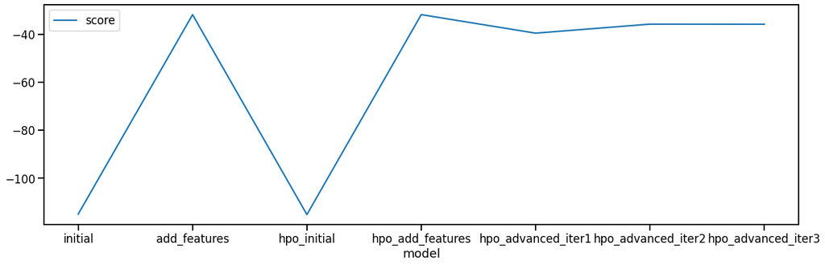

```python
# Taking the top model score from each training run and creating a line plot to show improvement
# You can create these in the notebook and save them to PNG or use some other tool (e.g. google sheets, excel)
fig = pd.DataFrame(
    {
        "model": ["initial", "add_features", "hpo_initial", "hpo_add_features", "hpo_advanced_iter1", "hpo_advanced_iter2", "hpo_advanced_iter3"],
        "score": [
            predictor.fit_summary(verbosity=0)['model_performance'][iter1_best_model],
            predictor_new_features.fit_summary(verbosity=0)['model_performance'][iter2_best_model],
            predictor_hpo_initial.fit_summary(verbosity=0)['model_performance'][iter3_best_model],
            predictor_hpo_more_features.fit_summary(verbosity=0)['model_performance'][iter4_best_model],
            predictor_new_hpo.fit_summary(verbosity=0)['model_performance'][iter5_best_model],
            predictor_new_hpo_2.fit_summary(verbosity=0)['model_performance'][iter6_best_model],
            predictor_new_hpo_3.fit_summary(verbosity=0)['model_performance'][iter7_best_model]
        ]
    }
).plot(kind="line", x="model", y="score", figsize=(20, 6)).get_figure()
fig.savefig('img/model_train_score.png')
```

```python
!kaggle competitions submissions -c bike-sharing-demand
```

```
fileName                          date                 description                            status    publicScore  privateScore
--------------------------------  -------------------  -------------------------------------  --------  -----------  ------------
submission_hpo_more_features.csv  2021-10-31 01:39:29  more features with basic hpo           complete  0.47117      0.47117
submission_hpo_initial.csv        2021-10-31 01:15:26  initial features with basic hpo        complete  1.38739      1.38739
submission_new_hpo_3.csv          2021-10-30 22:54:37  new features with hyperparameters #2   complete  0.46126      0.46126
submission_new_hpo_2.csv          2021-10-30 22:31:27  new features with hyperparameters #1   complete  0.46025      0.46025
submission_new_hpo.csv            2021-10-30 11:00:36  fnew features with hyperparameters #0  complete  0.49612      0.49612
submission_new_features.csv       2021-10-30 06:14:22  more features                          complete  0.45711      0.45711
submission.csv                    2021-10-30 05:02:39  first raw submission                   complete  1.39222      1.39222
submission.csv                    2021-10-30 05:01:53  first raw submission                   error     None         None
submission_new_features.csv       2021-10-29 10:39:34  new features                           complete  0.56750      0.56750
submission.csv                    2021-10-29 10:15:48  first raw submission                   complete  1.39426      1.39426
```

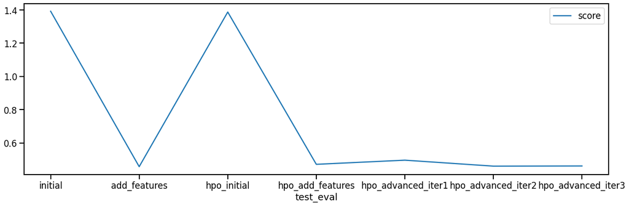

```python
# Take the 3 kaggle scores and creating a line plot to show improvement
fig = pd.DataFrame(
    {
        "test_eval": ["initial", "add_features", "hpo_initial", "hpo_add_features", "hpo_advanced_iter1", "hpo_advanced_iter2", "hpo_advanced_iter3"],
        "score": [1.39222, 0.45711, 1.38739, 0.47117, 0.49612, 0.46025, 0.46126]
    }
).plot(x="test_eval", y="score", figsize=(20, 6)).get_figure()
fig.savefig('img/model_test_score.png')
```

### Hyperparameter table

```python
# The 3 hyperparameters we tuned with the kaggle score as the result
pd.DataFrame({
    "model": [
        "initial", "add_features", "hpo initial (basic)", "hpo add_features (basic)",
        "hpo add_features (advanced) - NN and LightGBM", "hpo add_features (advanced) - more models", "hpo add_features w/o 'week' (advanced) - more models"
    ],
    "hpo1": ["N/A", "N/A", "N/A", "time_limit = 120", "time_limit = 120", "time_limit = 120", "time_limit = 120"],
    "hpo2": ["N/A", "N/A", "N/A", "num_trials = 5", "num_trials = 5", "num_trials = 5", "num_trials = 5"],
    "hpo3": ["N/A", "N/A", "N/A", "search_strategy = 'auto'", "search_strategy = 'auto'", "search_strategy = 'auto'", "search_strategy = 'auto'"],
    "score": [1.39222, 0.45711, 1.38739, 0.47117, 0.49612, 0.46025, 0.46126]
})
```

|  | model | hpo1 | hpo2 | hpo3 | score |
| --- | --- | --- | --- | --- | --- |
| 0 | initial | N/A | N/A | N/A | 1.39222 |
| 1 | add_features | N/A | N/A | N/A | 0.45711 |
| 2 | hpo initial (basic) | N/A | N/A | N/A | 1.38739 |
| 3 | hpo add_features (basic) | time_limit = 120 | num_trials = 5 | search_strategy = 'auto' | 0.47117 |
| 4 | hpo add_features (advanced) - NN and LightGBM | time_limit = 120 | num_trials = 5 | search_strategy = 'auto' | 0.49612 |
| 5 | hpo add_features (advanced) - more models | time_limit = 120 | num_trials = 5 | search_strategy = 'auto' | 0.46025 |
| 6 | hpo add_features w/o 'week' (advanced) - more models | time_limit = 120 | num_trials = 5 | search_strategy = 'auto' | 0.46126 |